# State Coronavirus Data

davegoblue

10/28/2020

## Background

This file is designed to analyze coronavirus data from a single state using three data sources:

- [The COVID Tracking Project](https://covidtracking.com/) contains state-level data for cases, deaths, tests, and hospitalizations
- [USA Facts](https://usafacts.org/visualizations/coronavirus-covid-19-spread-map/) contains county-level data for cases, deaths, and population
- [CDC Weekly Deaths by Jurisdiction](https://catalog.data.gov/dataset/weekly-counts-of-deaths-by-jurisdiction-and-age-group) contains state-level data for total deaths by age cohort

Data from each of these sources has been processed using code available in:

- Coronavirus_Statistics_CTP_v003
- Coronavirus_Statistics_USAF_v003
- Coronavirus_Statistics_CDC_v003

The goal of this file is to explore the measures for a single state. Data are generally available through late October (cases, deaths, tests, hospitalizations) and late August (all-cause deaths).

## Running Analyses

The process uses tidyverse throughout, and otherwise calls functions using library::function(). Further, a variable mapping file is used for readable plot axis labels, and shared functions are made available:

```r
library(tidyverse)
```

```r
source("./Coronavirus_Statistics_Functions_Shared_v003.R")

# Create a variable mapping file
varMapper <- c("cases"="Cases",
               "newCases"="Increase in cases, most recent 30 days",
               "casesroll7"="Rolling 7-day mean cases",
               "deaths"="Deaths",
               "newDeaths"="Increase in deaths, most recent 30 days",
               "deathsroll7"="Rolling 7-day mean deaths",
               "cpm"="Cases per million",
               "cpm7"="Cases per day (7-day rolling mean) per million",
               "newcpm"="Increase in cases, most recent 30 days, per million",
               "dpm"="Deaths per million",
               "dpm7"="Deaths per day (7-day rolling mean) per million",
               "newdpm"="Increase in deaths, most recent 30 days, per million",
               "hpm7"="Currently Hospitalized per million (7-day rolling mean)",
               "tpm"="Tests per million",
               "tpm7"="Tests per million per day (7-day rolling mean)",
               "cdcExcess"="Excess all-cause (CDC)",
               "ctp_death7"="COVID Tracking Project",
               "usaf_death7"="USA Facts",
               "CDC_deaths"="CDC total deaths",
               "CDC_excess"="CDC excess deaths",
               "CTP_cases"="COVID Tracking Project cases",
               "CTP_deaths"="COVID Tracking Project deaths",
               "CTP_hosp"="COVID Tracking Project hospitalized",
               "CTP_tests"="COVID Tracking Project tests",
               "USAF_cases"="USA Facts cases",
               "USAF_deaths"="USA Facts deaths",
               "vpm7"="Per million people (7-day rolling daily average)",
               "vpm"="Per million people"
               )
```

Data are loaded from files previously processed:

```r
ctpList <- readFromRDS("test_hier5_201025")
usafData <- readFromRDS("cty_20201026")$clusterStateData
cdcList <- readFromRDS("cdcList_20201027")
```

A function is written to examine the alignment of death data across the data sources for a single state:

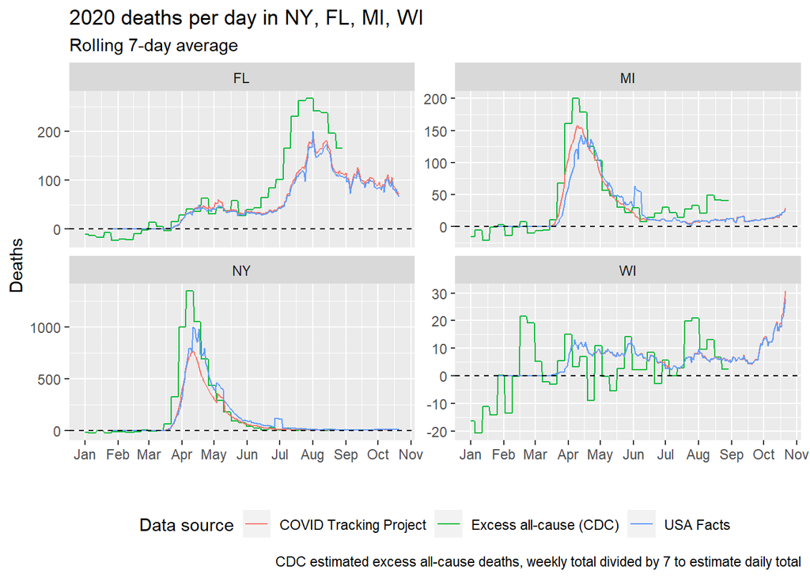

```r
combineDeathData <- function(ctp,
                             usaf,
                             cdc,
                             keyState,
                             curYear=2020,
                             minDate=as.Date(paste0(curYear, "-01-01")),
                             perMillion=FALSE,
                             glimpseIntermediate=FALSE,
                             facetFreeY=!perMillion,
                             returnData=TRUE
                             ) {

    # FUNCTION ARGUMENTS:
    # ctp: the list with COVID Tracking Project data
    # usaf: the data frame with USA Facts data
    # cdc: the list with CDC data
    # keyState: the state(s) to be explored
    # curYear: current year
    # minDate: the minimum date to use in the CDC data
    # perMillion: boolean, should data be show on a per-million-people basis?
    # glimpseIntermediate: boolean, should glimpses of frames be provided as they are built?
    # facetFreeY: boolean, should facets be created with free_y scales (only relevant if 2+ keyStates)
    # returnData: boolean, should the data frame be returned?

    # STEP 0a: Extract relevant elements from lists (use frame as-is if directly passed)
    if ("list" %in% class(ctp)) ctp <- ctp[["consolidatedPlotData"]]
    if ("list" %in% class(usaf)) usaf <- usaf[["clusterStateData"]]
    if ("list" %in% class(cdc)) cdc <- cdc[["stateAgg"]]

    # STEP 0b: Create a mapping file of date to epiWeek
    epiMap <- tibble::tibble(date=seq.Date(from=minDate, to=as.Date(paste0(curYear, "-12-31")), by="1 day"),
                             week=lubridate::epiweek(date)
                             )

    # STEP 1: Filter to only relevant data
    # STEP 1a: COVID Tracking Project
    ctp <- ctp %>%
        ungroup() %>%
        filter(name=="deaths", state %in% keyState)
    if(glimpseIntermediate) glimpse(ctp)
    # STEP 1b: USA Facts
    usaf <- usaf %>%
        ungroup() %>%
        filter(state %in% keyState)
    if(glimpseIntermediate) glimpse(usaf)
    # STEP 1c: CDC
    cdc <- cdc %>%
        ungroup() %>%
        filter(year==curYear, state %in% keyState)
    if(glimpseIntermediate) glimpse(cdc)

    # STEP 2a: Sum the county-level data so that it is state-level data
    usafState <- usaf %>%
        group_by(state, date) %>%
        summarize(deaths=sum(deaths), dpm7=sum(dpm7*pop)/sum(pop), pop=sum(pop)) %>%
        ungroup()
    # STEP 2b: Convert the CDC data to an estimated daily total (split the weekly total evenly)
    cdcDaily <- cdc %>%
        left_join(epiMap, by=c("week")) %>%
        select(state, week, date, cdcDeaths=deaths, cdcExcess=delta) %>%
        mutate(cdcDeaths=cdcDeaths/7, cdcExcess=cdcExcess/7)

    # STEP 3: Create a state death-level database by date
    dailyDeath <- select(ctp, state, date, ctpDeaths=value, ctp_dpm7=vpm7, ctp_pop=pop) %>%
        full_join(select(usafState, state, date, usafDeaths=deaths, usaf_dpm7=dpm7, usaf_pop=pop),
                  by=c("state", "date")
                  ) %>%
        full_join(cdcDaily, by=c("state", "date")) %>%
        arrange(state, date) %>%
        mutate(ctp_death7=ctp_dpm7*ctp_pop/1000000, usaf_death7=usaf_dpm7*usaf_pop/1000000)
    if(glimpseIntermediate) glimpse(dailyDeath)

    # STEP 4a: Assign a population by state
    statePop <- dailyDeath %>%
        group_by(state) %>%
        summarize(pop=max(usaf_pop, ctp_pop, na.rm=TRUE))

    # STEP 4b: Plot the deaths data
    p1 <- dailyDeath %>%
        select(state, date, ctp_death7, usaf_death7, cdcExcess) %>%
        pivot_longer(-c(state, date), names_to="source", values_to="deaths") %>%
        filter(!is.na(deaths)) %>%
        left_join(statePop, by="state") %>%
        ggplot(aes(x=date, y=deaths*if(perMillion) (1000000/pop) else 1)) +
        geom_line(aes(group=source, color=varMapper[source])) +
        labs(x="",
             y=paste0("Deaths", if(perMillion) " per million" else ""),
             title=paste0(curYear, " deaths per day in ", paste0(keyState, collapse=", ")),
             subtitle=paste0("Rolling 7-day average", if(perMillion) " per million people" else ""),
             caption="CDC estimated excess all-cause deaths, weekly total divided by 7 to estimate daily total"
             ) +
        scale_x_date(date_breaks="1 month", date_labels="%b") +
        scale_color_discrete("Data source") +
        theme(legend.position="bottom") +
        geom_hline(yintercept=0, lty=2)
    if (length(keyState) > 1) p1 <- p1 + facet_wrap(~state, scales=if(facetFreeY) "free_y" else "fixed")
    print(p1)

    # STEP 5: Return the daily death file
    if(returnData) dailyDeath

}

# Example function
combineDeathData(ctp=ctpList,
                 usaf=usafData,
                 cdc=cdcList,
                 keyState=c("NY", "FL", "MI", "WI"),
                 perMillion=FALSE,
                 returnData=FALSE
                 )
```

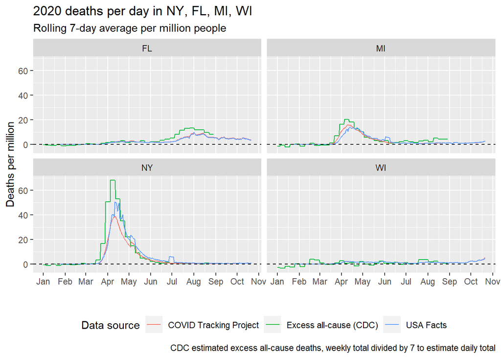

```r
combineDeathData(ctp=ctpList,
                 usaf=usafData,
                 cdc=cdcList,
                 keyState=c("NY", "FL", "MI", "WI"),
                 perMillion=TRUE,
                 returnData=FALSE
                 )
```

A different approach would be to combine all of the data, then to subset as needed for producing a given plot. Broadly, the data elements include:

- COVID Tracking Project (state-cluster-date-name-value-pop-vpm-vpm7) where name can be any of ‘cases’, ‘deaths’, ‘hosp’, or ‘tests’
- USA Facts (state-fipsCounty-date-cpm-dpm-cpm7-dpm7-cases-deaths-pop) where the data have not yet been pivoted to longer format nor summed to state
- CDC (state-year-week-deaths-delta) where the date have not yet been pivoted to longer format nor summed to state

Functions are written to create a main state-level database in the following format:

- State
- Date (will need to convert CDC from week to estimated date)
- Population (potentially helpful metric for conversions)
- State Cluster (potentially helpful metric for reporting)
- Metric (combine source and metric)
- Value
- Value Rolling 7
- Value per Million
- Value per Million rolling 7

Functions and example code include:

```r
# Function to convert a COVID Tracking Project file for further processing
prepCTPData <- function(ctp) {

    # FUNCTION AGRUMENTS:
    # ctp: a properly formatted list or data frame containing processed COVID Tracking Project data

    # Pull the relevant data frame if a list has been passed
    if ("list" %in% class(ctp)) ctp <- ctp[["consolidatedPlotData"]]

    # Ungroup the data, delete the state named 'cluster', and Create a value7 metric
    ctp <- ctp %>%
        ungroup() %>%
        filter(state != "cluster") %>%
        mutate(value7=ifelse(is.na(vpm7), NA, vpm7*pop/1000000))

    # Split state-cluster-population as a separate file unique by state
    ctpDemo <- ctp %>%
        group_by(state, cluster) %>%
        summarize(pop=max(pop, na.rm=TRUE)) %>%
        ungroup()

    # Create a final data file with the key elements
    ctpData <- ctp %>%
        rename(metric=name) %>%
        mutate(source="CTP", name=paste0(source, "_", metric)) %>%
        select(state, date, metric, source, name, value, value7, vpm, vpm7)

    # Return the key data frames
    list(ctpDemo=ctpDemo, ctpData=ctpData)

}

ctpPrepped <- prepCTPData(ctpList)
# Function to convert a USA Facts file for further processing
prepUSAFData <- function(usaf) {

    # FUNCTION AGRUMENTS:
    # usaf: a properly formatted list or data frame containing processed USA Facts data

    # Pull the relevant data frame if a list has been passed
    if ("list" %in% class(usaf)) usaf <- usaf[["clusterStateData"]]

    # Sum the data to state, keeping only state-date-pop-cases-deaths, then pivot longer
    usaf <- usaf %>%
        group_by(state, date) %>%
        summarize(cases=sum(cases), deaths=sum(deaths), pop=sum(pop)) %>%
        ungroup() %>%
        pivot_longer(-c(state, date, pop), names_to="metric", values_to="value")

    # Create the rolling-7 for value, having grouped by state-pop-metric and sorted by date
    # Add the per million component
    usaf <- usaf %>%
        group_by(state, pop, metric) %>%
        arrange(date) %>%
        helperRollingAgg(origVar="value", newName="value7") %>%
        ungroup() %>%
        mutate(vpm=value*1000000/pop, vpm7=value7*1000000/pop)

    # Split state-pop as a separate file unique by state
    usafDemo <- usaf %>%
        group_by(state) %>%
        summarize(pop=max(pop, na.rm=TRUE)) %>%
        ungroup()

    # Create a final data file with the key elements
    usafData <- usaf %>%
        mutate(source="USAF", name=paste0(source, "_", metric)) %>%
        select(state, date, metric, source, name, value, value7, vpm, vpm7)

    # Return the key data frames
    list(usafDemo=usafDemo, usafData=usafData)

}

usafPrepped <- prepUSAFData(usafData)
# Function to convert a CDC file for further processing
prepCDCData <- function(cdc,
                        popData,
                        startYear=2020,
                        startDate=as.Date(paste0(startYear, "-01-01")),
                        endDate=as.Date(paste0(startYear, "-12-31"))
                        ) {

    # FUNCTION AGRUMENTS:
    # cdc: a properly formatted list or data frame containing processed CDC data
    # popData: a file containing fields state-pop
    # startYear: starting year (CDC data will be filtered for this year and later)
    # startDate: the starting date for use in the mapping file to create daily estimates
    # endDate: the ending date for use in the mapping file to create daily estimates

    # Pull the relevant data frame if a list has been passed
    if ("list" %in% class(cdc)) cdc <- cdc[["stateAgg"]]

    # Create a mapping file of dates to epiweek-epiyear
    epiMap <- tibble::tibble(date=seq.Date(from=startDate, to=endDate, by="1 day"),
                             year=lubridate::epiyear(date),
                             week=lubridate::epiweek(date)
                             )

    # Filter the data to the relevant year and keep state-year-week-deaths-excess
    cdc <- cdc %>%
        filter(yearint >= startYear) %>%
        select(state, yearint, week, deaths, excess=delta)

    # Merge in the daily mapping file, divide all totals by 7 to reflect weekly to daily, and pivot longer
    cdc <- cdc %>%
        left_join(epiMap, by=c("yearint"="year", "week"="week")) %>%
        mutate(deaths=deaths/7, excess=excess/7) %>%
        select(state, date, deaths, excess) %>%
        pivot_longer(-c(state, date), names_to="metric", values_to="value")

    # Create the rolling-7 for value, having grouped by state-metric and sorted by date
    # Add the per million component
    cdc <- cdc %>%
        group_by(state, metric) %>%
        arrange(date) %>%
        helperRollingAgg(origVar="value", newName="value7") %>%
        ungroup() %>%
        left_join(select(popData, state, pop), by="state") %>%
        mutate(vpm=value*1000000/pop,
               vpm7=value7*1000000/pop,
               source="CDC",
               name=paste0(source, "_", metric)
               ) %>%
        select(state, date, pop, metric, source, name, value, value7, vpm, vpm7)

    # Return the key data frame as a list
    list(cdcDemo=select(cdc, state, pop), cdcData=select(cdc, -pop))

}

# Create an integrated state demographics file
demoData <- ctpPrepped$ctpDemo %>%
    rename(popCTP=pop) %>%
    full_join(rename(usafPrepped$usafDemo, popUSAF=pop), by="state") %>%
    mutate(pop=pmax(popCTP, popUSAF))

cdcPrepped <- prepCDCData(cdcList, popData=demoData)



# Integrated state data
stateData <- ctpPrepped$ctpData %>%
    bind_rows(usafPrepped$usafData) %>%
    bind_rows(cdcPrepped$cdcData)
glimpse(stateData)
```

```
## Rows: 98,931
## Columns: 9
## $ state  <chr> "AK", "AK", "AK", "AK", "AK", "AK", "AK", "AK", "AK", "AK", ...
## $ date   <date> 2020-03-06, 2020-03-07, 2020-03-08, 2020-03-09, 2020-03-10,...
## $ metric <chr> "cases", "cases", "cases", "cases", "cases", "cases", "cases...
## $ source <chr> "CTP", "CTP", "CTP", "CTP", "CTP", "CTP", "CTP", "CTP", "CTP...
## $ name   <chr> "CTP_cases", "CTP_cases", "CTP_cases", "CTP_cases", "CTP_cas...
## $ value  <dbl> 0, 0, 0, 0, 0, 0, 0, 1, 0, 0, 0, 2, 3, 0, 6, 2, 8, 0, 14, 6,...
## $ value7 <dbl> NA, NA, NA, 0.0000000, 0.1428571, 0.1428571, 0.1428571, 0.14...
## $ vpm    <dbl> 0.000000, 0.000000, 0.000000, 0.000000, 0.000000, 0.000000, ...
## $ vpm7   <dbl> NA, NA, NA, 0.0000000, 0.1934601, 0.1934601, 0.1934601, 0.19...
```

```r
# Control totals
stateData %>%
    group_by(name) %>%
    summarize(value=sum(value, na.rm=TRUE), value7=sum(value7, na.rm=TRUE))
```

```
## # A tibble: 8 x 3
##   name             value     value7
##   <chr>            <dbl>      <dbl>
## 1 CDC_deaths    2166309.   2114652.
## 2 CDC_excess     236718.    234468.
## 3 CTP_cases     8464908    8243331.
## 4 CTP_deaths     215758     212969.
## 5 CTP_hosp      8632281    8405618.
## 6 CTP_tests   130976369  127573841.
## 7 USAF_cases    8395819    8195223.
## 8 USAF_deaths    221247     218751.
```

A function is written to allow for plotting of data, optionally facetted by state:

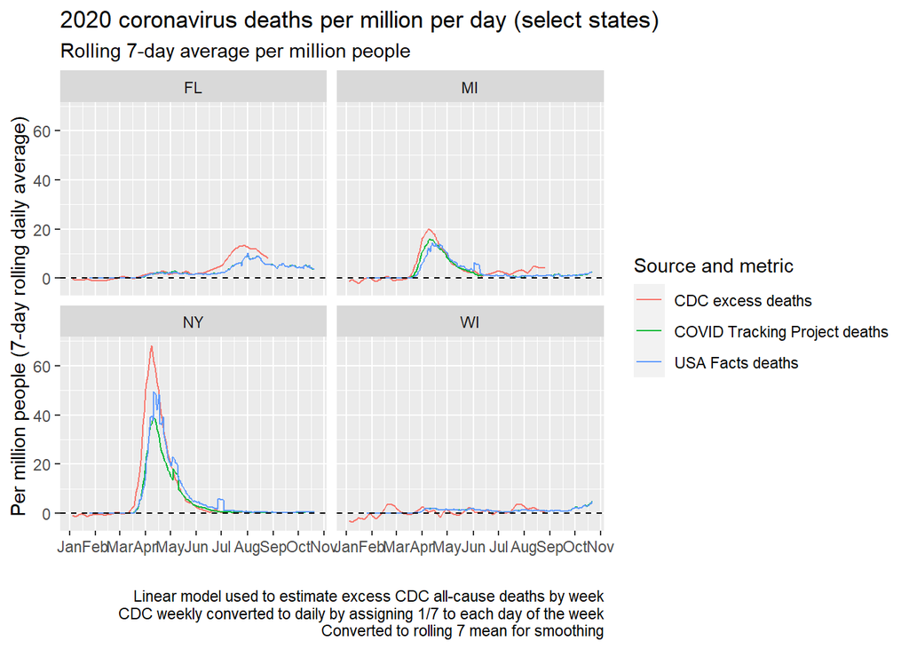

```r
plotStateMetric <- function(df,
                            yVal,
                            namesPlot,
                            keyStates,
                            plotTitle=NULL,
                            plotSub=NULL,
                            plotCaption=NULL,
                            facetFixed=TRUE,
                            mapper=varMapper
                            ) {

    # FUNCTION ARGUMENTS:
    # df: data frame with integrated state data
    # yVal: column to use for the yValues
    # namesPlot: the values of column 'name' to be kept and plotted
    # keyStates: states to be included
    #            if more than one state is passed, facets will be created
    # plotTitle: plot title to be used (NULL means none)
    # plotSub: plot subtitle to be used (NULL means none)
    # plotCaption: plot caption to be used (NULL means none)
    # facetFixed: boolean, if TRUE scales="fixed", if FALSE scales="free_y"
    #             only relevant if length(keyStates) > 1

    # Filter the data for only the key elements
    df <- df %>%
        select_at(vars(all_of(c("state", "date", "name", yVal)))) %>%
        filter(state %in% keyStates, name %in% namesPlot)

    # Create the relevant line plot
    p1 <- df %>%
        filter(!is.na(get(yVal))) %>%
        ggplot(aes_string(x="date", y=yVal)) +
        geom_line(aes(group=name, color=mapper[name])) +
        labs(x="",
             y=mapper[yVal]
             ) +
        scale_x_date(date_breaks="1 month", date_labels="%b") +
        scale_color_discrete("Source and metric") +
        geom_hline(aes(yintercept=0), lty=2)
    if (length(keyStates) > 1) p1 <- p1 + facet_wrap(~state, scales=if(facetFixed) "fixed" else "free_y")
    if (!is.null(plotTitle)) p1 <- p1 + labs(title=plotTitle)
    if (!is.null(plotSub)) p1 <- p1 + labs(subtitle=plotSub)
    if (!is.null(plotCaption)) p1 <- p1 + labs(caption=plotCaption)
    print(p1)

}

plotStateMetric(stateData,
                yVal="vpm7",
                namesPlot=c("CDC_excess", "CTP_deaths", "USAF_deaths"),
                keyStates=c("NY", "FL", "MI", "WI"),
                plotTitle="2020 coronavirus deaths per million per day (select states)",
                plotSub="Rolling 7-day average per million people",
                plotCaption=paste0("Linear model used to estimate excess CDC all-cause deaths by week\n",
                                   "CDC weekly converted to daily by assigning 1/7 to each day of the week\n",
                                   "Converted to rolling 7 mean for smoothing"
                                   ),
                facetFixed=TRUE
                )
```

Cases per million can be assessed using the same function:

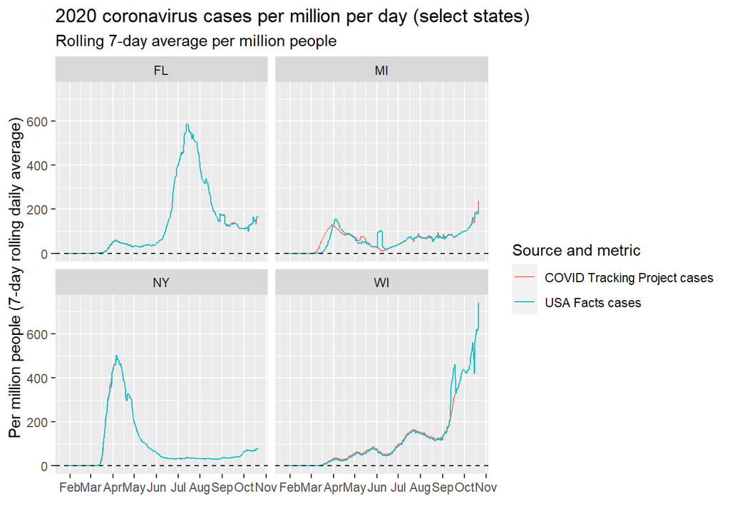

```r
plotStateMetric(stateData,
                yVal="vpm7",
                namesPlot=c("CTP_cases", "USAF_cases"),
                keyStates=c("NY", "FL", "MI", "WI"),
                plotTitle="2020 coronavirus cases per million per day (select states)",
                plotSub="Rolling 7-day average per million people",
                facetFixed=TRUE
                )
```

Tests per million can be assessed using the same function:

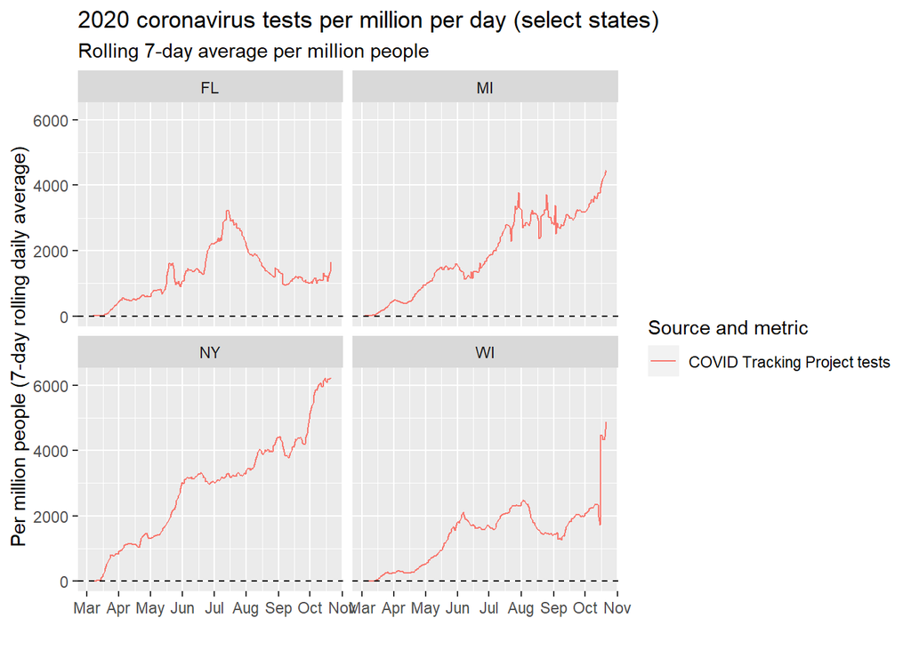

```r
plotStateMetric(stateData,
                yVal="vpm7",
                namesPlot=c("CTP_tests"),
                keyStates=c("NY", "FL", "MI", "WI"),
                plotTitle="2020 coronavirus tests per million per day (select states)",
                plotSub="Rolling 7-day average per million people",
                facetFixed=TRUE
                )
```

Hospitalized per million can be assessed using the same function:

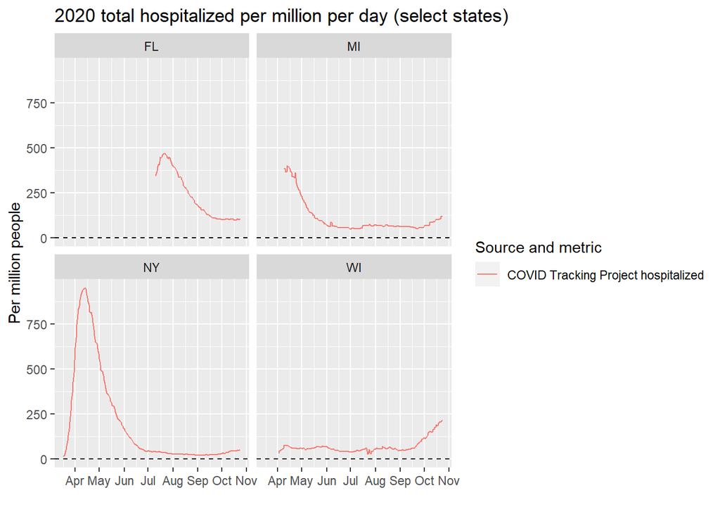

```r
plotStateMetric(stateData,
                yVal="vpm",
                namesPlot=c("CTP_hosp"),
                keyStates=c("NY", "FL", "MI", "WI"),
                plotTitle="2020 total hospitalized per million per day (select states)",
                facetFixed=TRUE
                )
```

Suppose that the goal is to use two axes to plot metrics with fundamentally differing scales (e.g., cases and deaths). The function plotStateMetric() is updated to allow for a secondary axis:

```
##
## Will scale by: 21.6566
```

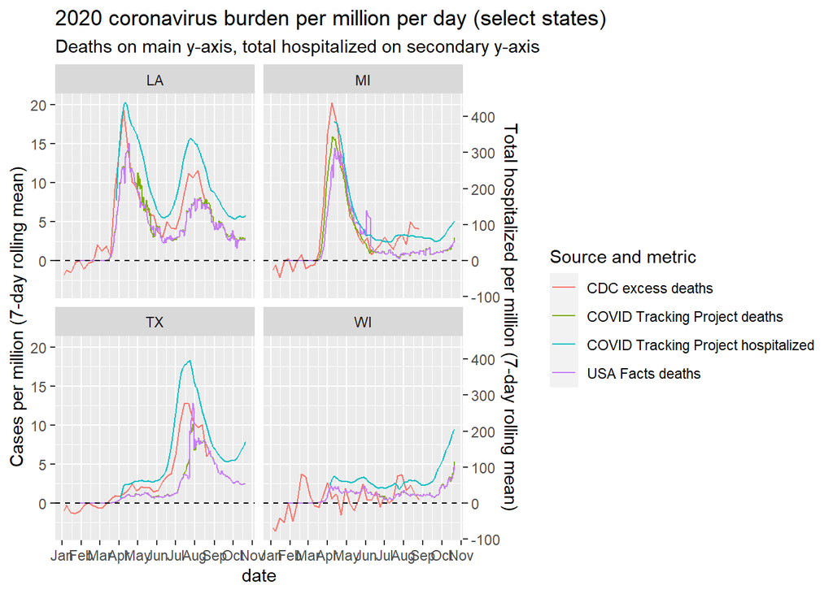

```r
plotStateMetric <- function(df,
                            yVal,
                            namesPlot,
                            keyStates,
                            namesSec=NULL,
                            scaleSec=NULL,
                            plotTitle=NULL,
                            plotSub=NULL,
                            plotCaption=NULL,
                            primYLab=NULL,
                            secYLab="Caution, different metric and scale",
                            facetFixed=TRUE,
                            mapper=varMapper
                            ) {

    # FUNCTION ARGUMENTS:
    # df: data frame with integrated state data
    # yVal: column to use for the yValues
    # namesPlot: the values of column 'name' to be kept and plotted
    # keyStates: states to be included
    #            if more than one state is passed, facets will be created
    # namesSec: names to be plotted on a secondary y-axes
    # scaleSec: scale to be used for the secondary axis
    #           namesSec/scaleSec should be similar in magnitude to namesPlot
    # plotTitle: plot title to be used (NULL means none)
    # plotSub: plot subtitle to be used (NULL means none)
    # plotCaption: plot caption to be used (NULL means none)
    # primYLab: primary y label (NULL means use mapper)
    # secYLab: secondary y label (default is "Caution, different metric and scale")
    # facetFixed: boolean, if TRUE scales="fixed", if FALSE scales="free_y"
    #             only relevant if length(keyStates) > 1

    # Routine is only set up for a secondary axis with facetFixed=TRUE
    if (!is.null(namesSec) & !facetFixed) stop("\nSecondary axis only programmed for scales='fixed'\n")

    # Include variables in namesSec as part of namesPlot so they are kept by filter
    if (!is.null(namesSec)) namesPlot <- unique(c(namesPlot, namesSec))

    # Filter the data for only the key elements
    df <- df %>%
        select_at(vars(all_of(c("state", "date", "name", yVal)))) %>%
        filter(state %in% keyStates, name %in% namesPlot)

    # If there is a secondary scale but no scaleSec has been passed, create one
    if (!is.null(namesSec) & is.null(scaleSec)) {
        maxPrimary <- df %>%
            filter(name %in% setdiff(namesPlot, namesSec)) %>%
            summarize(max(get(yVal), na.rm=TRUE)) %>%
            max()
        maxSecondary <- df %>%
            filter(name %in% namesSec) %>%
            summarize(max(get(yVal), na.rm=TRUE)) %>%
            max()
        scaleSec <- maxSecondary/maxPrimary
        cat("\nWill scale by:", scaleSec, "\n")
    }

    # Create the primary y-axis label from mapper if it has not been passed
    if (is.null(primYLab)) primYLab <- mapper[yVal]

    # Create the relevant line plot
    p1 <- df %>%
        filter(!is.na(get(yVal))) %>%
        ggplot(aes_string(x="date")) +
        geom_line(data=~filter(., name %in% setdiff(namesPlot, namesSec)),
                  aes(y=get(yVal), group=name, color=mapper[name])
                  ) +
        scale_x_date(date_breaks="1 month", date_labels="%b") +
        geom_hline(aes(yintercept=0), lty=2)
    if (!is.null(namesSec)) {
        p1 <- p1 +
            geom_line(data=~filter(., name %in% namesSec),
                      aes(y=get(yVal)/scaleSec, color=mapper[name], group=name)
                      ) +
            scale_y_continuous(name=primYLab,
                               sec.axis=sec_axis(~.*scaleSec, name=secYLab)
                               )
    } else {
        p1 <- p1 + scale_y_continuous(name=primYLab)
    }
    if (length(keyStates) > 1) p1 <- p1 + facet_wrap(~state, scales=if(facetFixed) "fixed" else "free_y")
    if (!is.null(plotTitle)) p1 <- p1 + labs(title=plotTitle)
    if (!is.null(plotSub)) p1 <- p1 + labs(subtitle=plotSub)
    if (!is.null(plotCaption)) p1 <- p1 + labs(caption=plotCaption)
    p1 <- p1 + scale_color_discrete("Source and metric")
    print(p1)

}


plotStateMetric(stateData,
                yVal="vpm7",
                namesPlot=c("CDC_excess", "USAF_deaths", "CTP_deaths"),
                namesSec=c("CTP_hosp"),
                keyStates=c("LA", "TX", "MI", "WI"),
                plotTitle="2020 coronavirus burden per million per day (select states)",
                plotSub="Deaths on main y-axis, total hospitalized on secondary y-axis",
                primYLab="Cases per million (7-day rolling mean)",
                secYLab="Total hospitalized per million (7-day rolling mean)",
                facetFixed=TRUE
                )
```

```
##
## Will scale by: 0.5920434
```

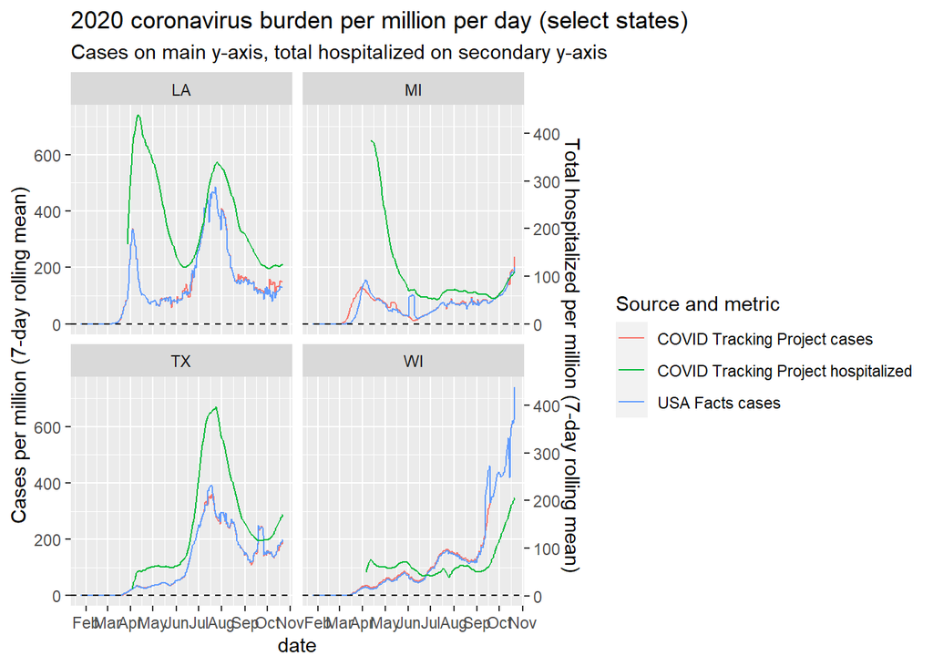

```r
plotStateMetric(stateData,
                yVal="vpm7",
                namesPlot=c("USAF_cases", "CTP_cases"),
                namesSec=c("CTP_hosp"),
                keyStates=c("LA", "TX", "MI", "WI"),
                plotTitle="2020 coronavirus burden per million per day (select states)",
                plotSub="Cases on main y-axis, total hospitalized on secondary y-axis",
                primYLab="Cases per million (7-day rolling mean)",
                secYLab="Total hospitalized per million (7-day rolling mean)",
                facetFixed=TRUE
                )
```

```
##
## Will scale by: 0.02138943
```

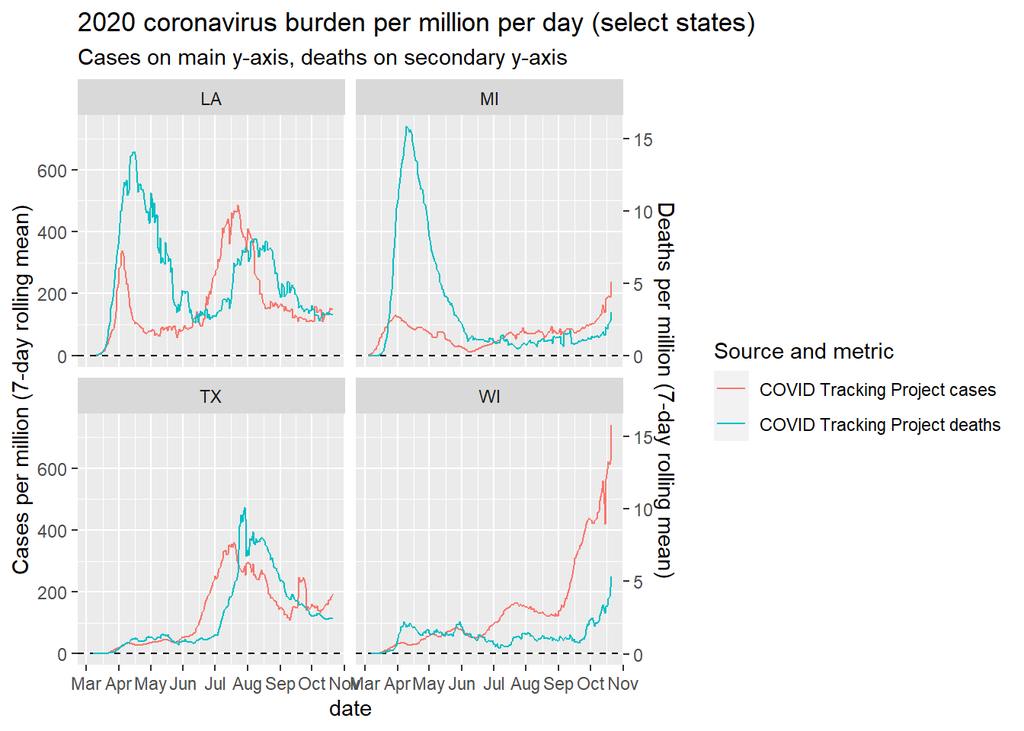

```r
plotStateMetric(stateData,
                yVal="vpm7",
                namesPlot=c("CTP_cases"),
                namesSec=c("CTP_deaths"),
                keyStates=c("LA", "TX", "MI", "WI"),
                plotTitle="2020 coronavirus burden per million per day (select states)",
                plotSub="Cases on main y-axis, deaths on secondary y-axis",
                primYLab="Cases per million (7-day rolling mean)",
                secYLab="Deaths per million (7-day rolling mean)",
                facetFixed=TRUE
                )
```

The function plotStateMetric() is updated so that multiple states can be combined and tracked as a single entity:

```r
plotStateMetric <- function(df,
                            yVal,
                            namesPlot,
                            keyStates,
                            namesSec=NULL,
                            scaleSec=NULL,
                            plotTitle=NULL,
                            plotSub=NULL,
                            plotCaption=NULL,
                            primYLab=NULL,
                            secYLab="Caution, different metric and scale",
                            facetFixed=TRUE,
                            mapper=varMapper,
                            combStates=vector("character", 0),
                            popData=NULL,
                            yValPerCap=(yVal %in% c("vpm", "vpm7")),
                            printPlot=TRUE,
                            returnData=FALSE
                            ) {

    # FUNCTION ARGUMENTS:
    # df: data frame with integrated state data
    # yVal: column to use for the yValues
    # namesPlot: the values of column 'name' to be kept and plotted
    # keyStates: states to be included
    #            if more than one state is passed, facets will be created
    # namesSec: names to be plotted on a secondary y-axes
    # scaleSec: scale to be used for the secondary axis
    #           namesSec/scaleSec should be similar in magnitude to namesPlot
    # plotTitle: plot title to be used (NULL means none)
    # plotSub: plot subtitle to be used (NULL means none)
    # plotCaption: plot caption to be used (NULL means none)
    # primYLab: primary y label (NULL means use mapper)
    # secYLab: secondary y label (default is "Caution, different metric and scale")
    # facetFixed: boolean, if TRUE scales="fixed", if FALSE scales="free_y"
    #             only relevant if length(keyStates) > 1
    # mapper: mapping file for variable names to descriptive names
    # combStates: states that should be combined together for plotting (named vector, c("state"="newName"))
    # popData: a population file for combining states
    # yValPerCap: boolean, is the y-value of type per-capita?
    # printPlot: boolean, whether to print the plots
    # returnData: boolean, whether to return the data

    # Routine is only set up for a secondary axis with facetFixed=TRUE
    if (!is.null(namesSec) & !facetFixed) stop("\nSecondary axis only programmed for scales='fixed'\n")

    # Include variables in namesSec as part of namesPlot so they are kept by filter
    if (!is.null(namesSec)) namesPlot <- unique(c(namesPlot, namesSec))

    # Filter the data for only the key elements
    df <- df %>%
        select_at(vars(all_of(c("state", "date", "name", yVal)))) %>%
        filter(state %in% keyStates, name %in% namesPlot)

    # If there is a list of states to combine, process them
    if (length(combStates) > 0) {
        if (is.null(popData)) { stop("\nCombining states requires population data\n") }
        # Create a data frame with population and new state names
        df <- df %>%
            left_join(select(popData, state, pop), by="state") %>%
            mutate(state=ifelse(state %in% names(combStates), combStates[state], state))
        # Aggregate to the new 'state' level data
        if (yValPerCap) {
            df <- df %>%
                group_by(state, date, name) %>%
                summarize(!!yVal:=sum(get(yVal)*pop)/sum(pop), pop=sum(pop))
        } else {
            df <- df %>%
                group_by(state, date, name) %>%
                summarize(!!yVal:=sum(get(yVal)), pop=sum(pop))
        }
        # Ungroup data frame
        df <- df %>%
            ungroup()
    }

    # If there is a secondary scale but no scaleSec has been passed, create one
    if (!is.null(namesSec) & is.null(scaleSec)) {
        maxPrimary <- df %>%
            filter(name %in% setdiff(namesPlot, namesSec)) %>%
            summarize(max(get(yVal), na.rm=TRUE)) %>%
            max()
        maxSecondary <- df %>%
            filter(name %in% namesSec) %>%
            summarize(max(get(yVal), na.rm=TRUE)) %>%
            max()
        scaleSec <- maxSecondary/maxPrimary
        cat("\nWill scale by:", scaleSec, "\n")
    }

    # Create the primary y-axis label from mapper if it has not been passed
    if (is.null(primYLab)) primYLab <- mapper[yVal]

    # Create the relevant line plot
    if (printPlot) {
        p1 <- df %>%
            filter(!is.na(get(yVal))) %>%
            ggplot(aes_string(x="date")) +
            geom_line(data=~filter(., name %in% setdiff(namesPlot, namesSec)),
                      aes(y=get(yVal), group=name, color=mapper[name])
                      ) +
            scale_x_date(date_breaks="1 month", date_labels="%b") +
            geom_hline(aes(yintercept=0), lty=2) +
            labs(x="") +
            theme(axis.text.x = element_text(angle = 90))
        if (!is.null(namesSec)) {
            p1 <- p1 +
                geom_line(data=~filter(., name %in% namesSec),
                          aes(y=get(yVal)/scaleSec, color=mapper[name], group=name)
                          ) +
                scale_y_continuous(name=primYLab,
                                   sec.axis=sec_axis(~.*scaleSec, name=secYLab)
                                   )
        } else {
            p1 <- p1 + scale_y_continuous(name=primYLab)
        }
        if (length(keyStates) > 1) p1 <- p1 + facet_wrap(~state, scales=if(facetFixed) "fixed" else "free_y")
        if (!is.null(plotTitle)) p1 <- p1 + labs(title=plotTitle)
        if (!is.null(plotSub)) p1 <- p1 + labs(subtitle=plotSub)
        if (!is.null(plotCaption)) p1 <- p1 + labs(caption=plotCaption)
        p1 <- p1 + scale_color_discrete("Source and metric")
        print(p1)
    }

    if (returnData) return(df)

}
```

```r
# Example of combining states (created below with data returned)
plotStateMetric(stateData,
                yVal="vpm7",
                namesPlot=c("CTP_cases"),
                namesSec=c("CTP_deaths"),
                keyStates=c("NY", "NJ", "MA", "CT", "RI", "NH", "VT", "ME"),
                combStates=c("MA"="S NE", "CT"="S NE", "RI"="S NE", "NH"="N NE", "VT"="N NE", "ME"="N NE"),
                plotTitle="2020 coronavirus burden per million per day (select states)",
                plotSub="Cases on main y-axis, deaths on secondary y-axis",
                primYLab="Cases per million (7-day rolling mean)",
                secYLab="Deaths per million (7-day rolling mean)",
                facetFixed=TRUE,
                popData=usafPrepped$usafDemo
                )
```

The sparsely populated states of northern New England (Maine, New Hampshire, Vermont) have very different coronavirus burden than the more densely populated states of southern New England (Massachusetts, Connecticut, Rhode Island).

The function is updated so that it can create a plot and/or return a dataset:

```
##
## Will scale by: 0.07901078
```

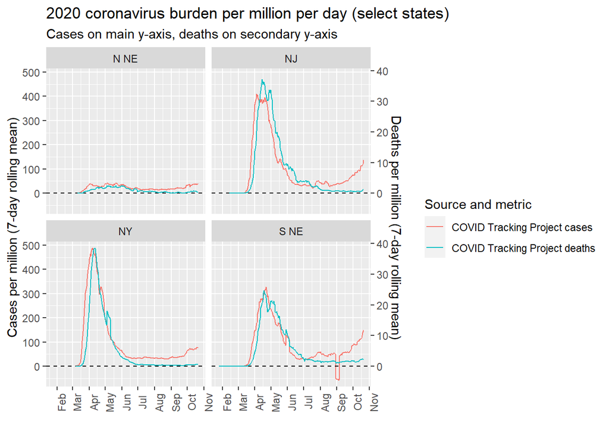

```r
# Example of combining states
ne_casedeath <- plotStateMetric(stateData,
                                yVal="vpm7",
                                namesPlot=c("CTP_cases"),
                                namesSec=c("CTP_deaths"),
                                keyStates=c("NY", "NJ", "MA", "CT", "RI", "NH", "VT", "ME"),
                                combStates=c("MA"="S NE", "CT"="S NE", "RI"="S NE",
                                             "NH"="N NE", "VT"="N NE", "ME"="N NE"
                                             ),
                                plotTitle="2020 coronavirus burden per million per day (select states)",
                                plotSub="Cases on main y-axis, deaths on secondary y-axis",
                                primYLab="Cases per million (7-day rolling mean)",
                                secYLab="Deaths per million (7-day rolling mean)",
                                facetFixed=TRUE,
                                popData=usafPrepped$usafDemo,
                                returnData=TRUE
                                )
```

```r
ne_casedeath
```

```
## # A tibble: 2,010 x 5
##    state date       name        vpm7     pop
##    <chr> <date>     <chr>      <dbl>   <dbl>
##  1 N NE  2020-03-04 CTP_cases     NA 1330608
##  2 N NE  2020-03-04 CTP_deaths    NA 1330608
##  3 N NE  2020-03-05 CTP_cases     NA 1330608
##  4 N NE  2020-03-05 CTP_deaths    NA 1330608
##  5 N NE  2020-03-06 CTP_cases     NA 1956650
##  6 N NE  2020-03-06 CTP_deaths    NA 1956650
##  7 N NE  2020-03-07 CTP_cases     NA 3285978
##  8 N NE  2020-03-07 CTP_deaths    NA 3285978
##  9 N NE  2020-03-08 CTP_cases     NA 3285978
## 10 N NE  2020-03-08 CTP_deaths    NA 3285978
## # ... with 2,000 more rows
```

Suppose that the goal is to come up with a single transform on two dimensions to best match the curves to each other. One dimension is time (up to 30 days) and the other dimension is magnitude:

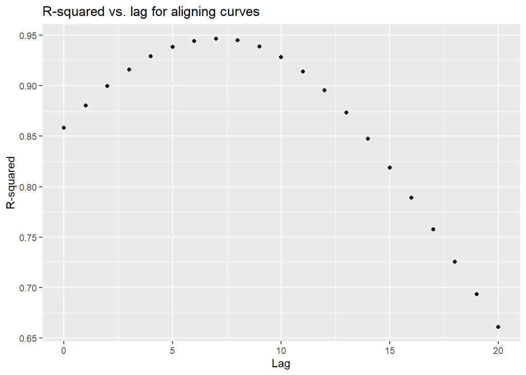

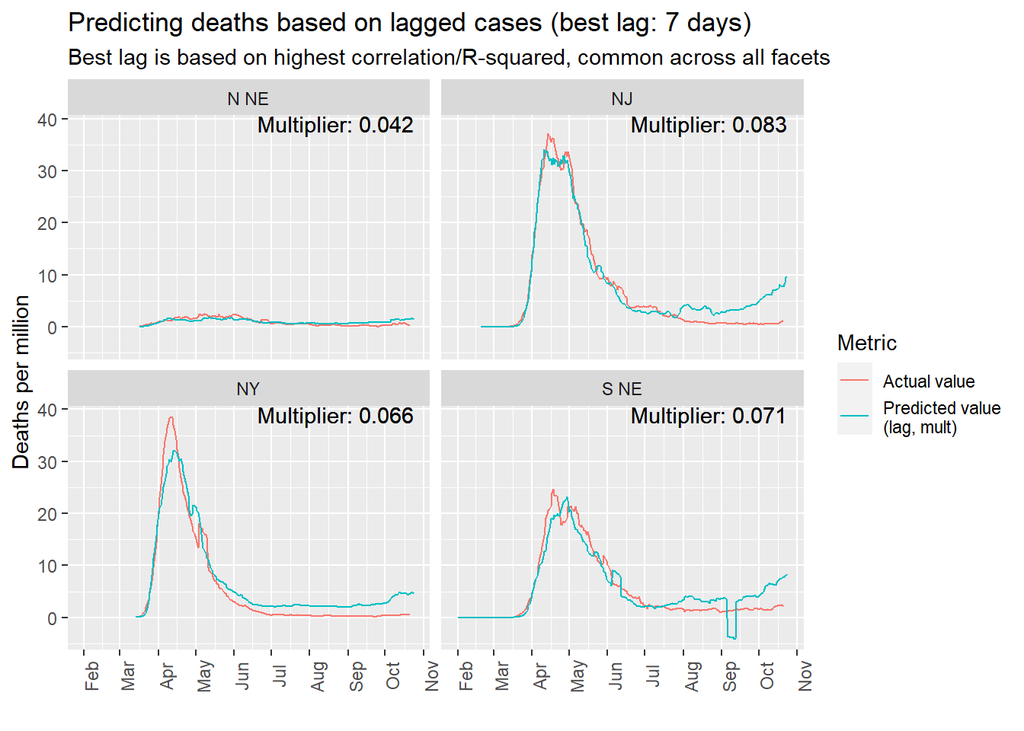

```r
alignCurves <- function(df,
                        valueMetric,
                        depName,
                        indepName=setdiff(unique(df$name), depName),
                        lagsTry=0:30,
                        yLabel="Deaths per million",
                        depLabel="cases",
                        textMetric=stringr::str_split(yLabel, pattern=" ")[[1]][1] %>% stringr::str_to_lower()
                        ) {

    # FUNCTION ARGUMENTS
    # df: a data frame containing state-date-name-valueMetric, with only 2 value types in 'name'
    # valueMetric: the name of the value metric
    # depName: the name of the dependent variable (the other will be the predictor)
    # indepName: the name of the predictor variable
    # lagsTry: the lagged values to attempt
    # yLabel: label for the y-axis
    # depLabel: label for the title (regression x-variable name)
    # textMetric: label for the title (regression y-variable name)

    # Check that there are only two values in column 'name'
    if (length(unique(df$name))!=2) { stop("\nFunction depends on 'name' having only two possible values\n") }

    # Arrange the data by state and date
    df <- df %>%
        arrange(state, date)

    # Function to make a data frame with a specific lag
    helperMakeLagData <- function(df, depName, indepName, valueMetric, lagValue) {
        depData <- df %>%
            filter(name==depName) %>%
            select_at(vars(all_of(c("state", "date", valueMetric)))) %>%
            purrr::set_names(c("state", "date", "depVar"))
        indepData <- df %>%
            filter(name==indepName) %>%
            group_by(state) %>%
            mutate(indepVar=lag(get(valueMetric), lagValue)) %>%
            ungroup() %>%
            select(state, date, indepVar)
        fullData <- depData %>%
            full_join(indepData, by=c("state", "date"))
        fullData
    }

    # Run a simple linear model for depName ~ lag(otherName, lagsTry) to assess performance
    lmResults <- vector("list", length(lagsTry))
    n <- 1
    for (lagValue in lagsTry) {
        # Run the linear model with no intercept, save, and increment
        lmResults[[n]] <- lm(depVar ~ indepVar:state + 0,
                             data=helperMakeLagData(df,
                                                    depName=depName,
                                                    indepName=indepName,
                                                    valueMetric=valueMetric,
                                                    lagValue=lagValue
                                                    )
                             )
        n <- n + 1
    }

    # Find the best lag and coefficients
    dfResults <- tibble::tibble(lags=lagsTry,
                                rsq=sapply(lmResults, FUN=function(x) summary(x)$r.squared)
                                )
    p1 <- dfResults %>%
        ggplot(aes(x=lags, y=rsq)) +
        geom_point() +
        labs(x="Lag", y="R-squared", title="R-squared vs. lag for aligning curves")
    print(p1)

    # Calculate the best lag and coefficients
    bestLag <- dfResults %>%
        filter(rsq==max(rsq)) %>%
        pull(lags)
    bestCoef <- coef(lmResults[[which(lagsTry==bestLag)]]) %>%
        as.data.frame() %>%
        purrr::set_names("mult") %>%
        tibble::rownames_to_column("state") %>%
        mutate(state=str_replace(state, "indepVar:state", ""))

    # Plot the curves using the coefficients and lags
    bestDF <- helperMakeLagData(df,
                                depName=depName,
                                indepName=indepName,
                                valueMetric=valueMetric,
                                lagValue=bestLag
                                ) %>%
        filter(!is.na(indepVar)) %>%
        left_join(bestCoef, by="state") %>%
        mutate(pred=mult*indepVar)
    p2 <- bestDF %>%
        select(state, date, depVar, pred, mult) %>%
        pivot_longer(-c(state, date, mult)) %>%
        mutate(name=case_when(name=="depVar" ~ "Actual value",
                              name=="pred" ~ "Predicted value\n(lag, mult)",
                              TRUE ~ "Unknown Element"
                              )
               ) %>%
        ggplot(aes(x=date, y=value)) +
        geom_line(aes(group=name, color=name)) +
        geom_text(data=~filter(., date==max(date)),
                  aes(x=date, y=+Inf, label=paste0("Multiplier: ", round(mult, 3))),
                  hjust=1,
                  vjust=1
                  ) +
        labs(x="",
             y=yLabel,
             title=paste0("Predicting ",
                          textMetric,
                          " based on lagged ",
                          depLabel,
                          " (best lag: ",
                          bestLag,
                          " days)"
                          ),
             subtitle="Best lag is based on highest correlation/R-squared, common across all facets"
             ) +
        facet_wrap(~state) +
        scale_x_date(date_breaks="1 month", date_labels="%b") +
        theme(axis.text.x = element_text(angle = 90)) +
        scale_color_discrete("Metric")
    print(p2)

    # Return the key data
    list(bestLag=bestLag, bestCoef=bestCoef, bestDF=bestDF, lmResults=lmResults)

}

lmOut_ne <- alignCurves(ne_casedeath, valueMetric="vpm7", depName="CTP_deaths", lagsTry=0:20)
```

```
##
## Will scale by: 0.02075921
```

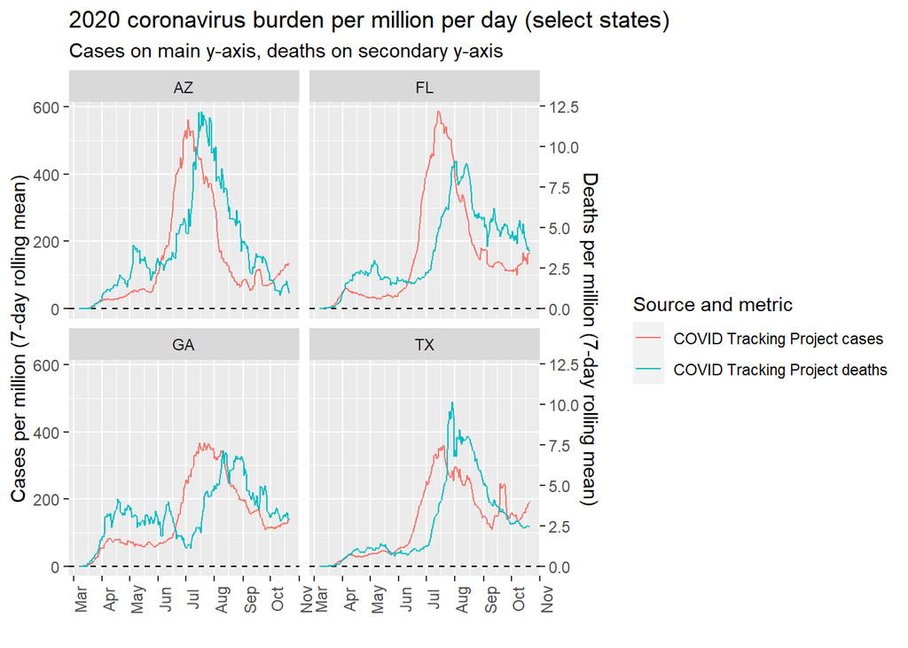

```r
# States with later deaths
so_casedeath <- plotStateMetric(stateData,
                                yVal="vpm7",
                                namesPlot=c("CTP_cases"),
                                namesSec=c("CTP_deaths"),
                                keyStates=c("FL", "GA", "TX", "AZ"),
                                plotTitle="2020 coronavirus burden per million per day (select states)",
                                plotSub="Cases on main y-axis, deaths on secondary y-axis",
                                primYLab="Cases per million (7-day rolling mean)",
                                secYLab="Deaths per million (7-day rolling mean)",
                                facetFixed=TRUE,
                                popData=usafPrepped$usafDemo,
                                returnData=TRUE
                                )
```

```r
so_casedeath
```

```
## # A tibble: 1,880 x 4
##    state date       name         vpm7
##    <chr> <date>     <chr>       <dbl>
##  1 AZ    2020-03-04 CTP_cases NA
##  2 AZ    2020-03-05 CTP_cases NA
##  3 AZ    2020-03-06 CTP_cases NA
##  4 AZ    2020-03-07 CTP_cases  0.0837
##  5 AZ    2020-03-08 CTP_cases  0.146
##  6 AZ    2020-03-09 CTP_cases  0.146
##  7 AZ    2020-03-10 CTP_cases  0.126
##  8 AZ    2020-03-11 CTP_cases  0.146
##  9 AZ    2020-03-12 CTP_cases  0.146
## 10 AZ    2020-03-13 CTP_cases  0.272
## # ... with 1,870 more rows
```

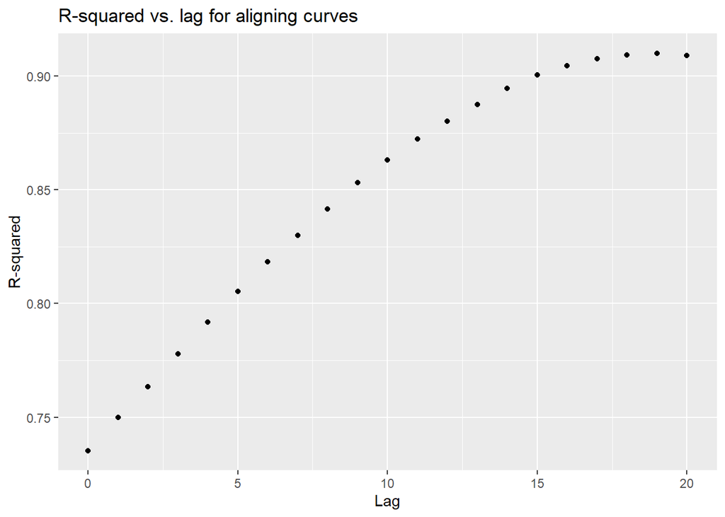

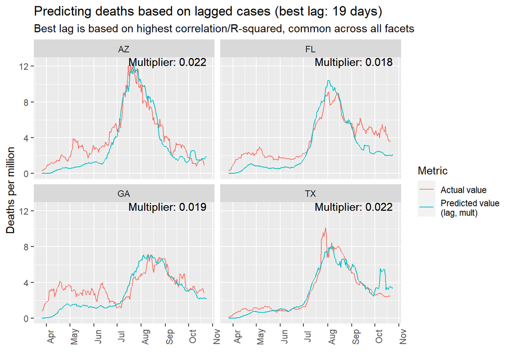

```r
lmOut_so <- alignCurves(so_casedeath, valueMetric="vpm7", depName="CTP_deaths", lagsTry=0:20)
```

The states with later disease burden seem to have 1) longer lag time from case to death; and 2) lower rate of deaths per case. Both findings would be consistent with greater testing leading to both earlier diagnosis and increased diagnosis of less severe cases.

The process can all be run together with a main function:

```
##
## Will scale by: 0.07975869
```

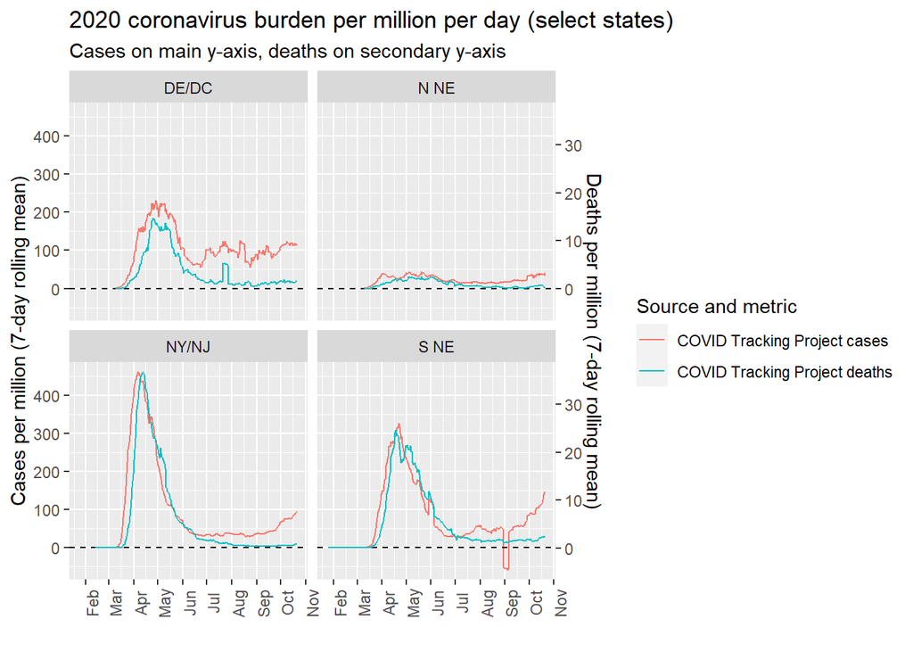

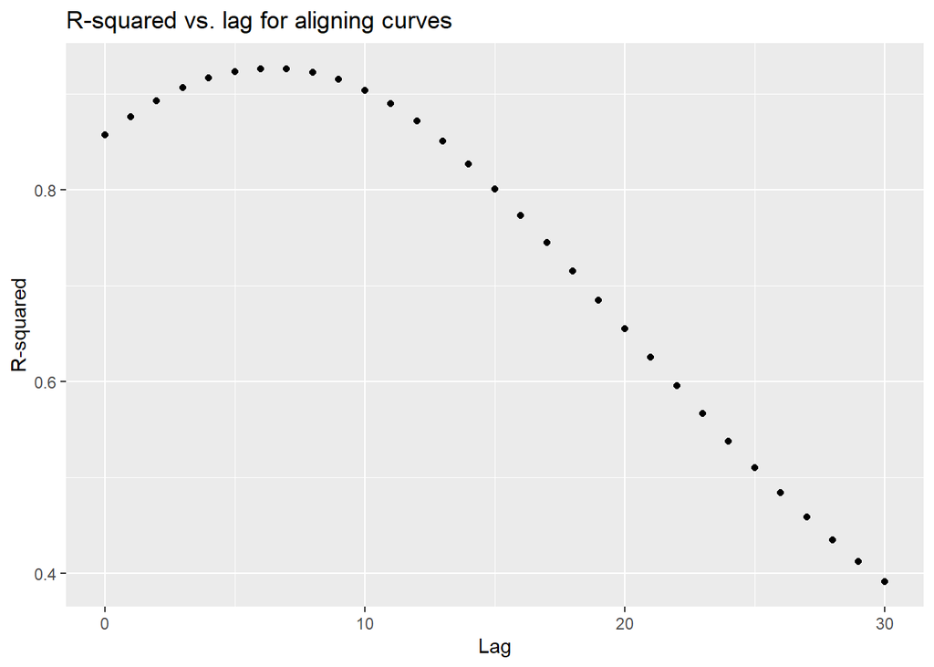

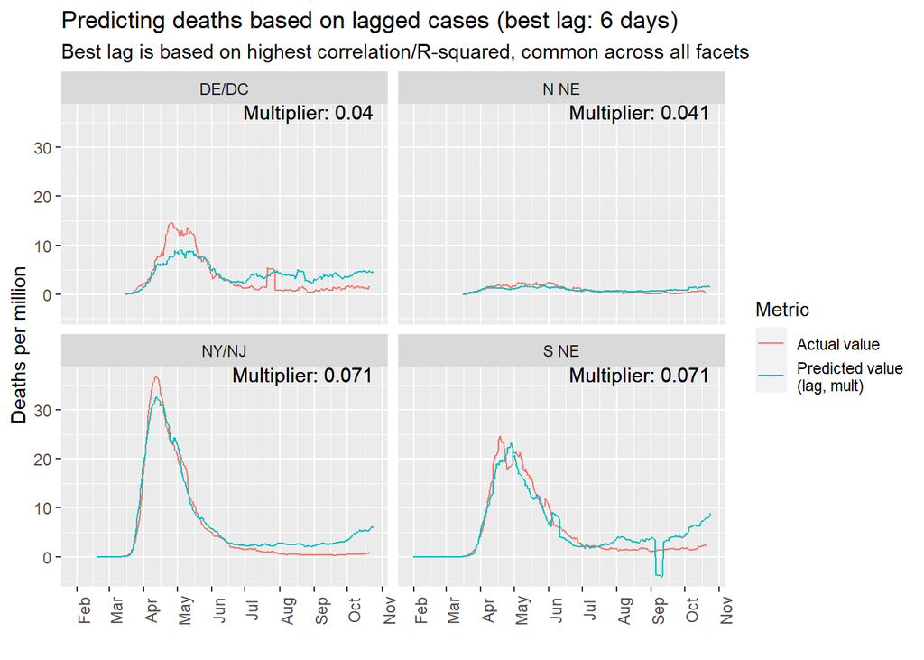

```r
createAndAlignCurves <- function(df,
                                 yVal,
                                 namesPlot,
                                 keyStates,
                                 lagValueMetric,
                                 lagDepName,
                                 namesSec=NULL,
                                 scaleSec=NULL,
                                 plotTitle=NULL,
                                 plotSub=NULL,
                                 plotCaption=NULL,
                                 primYLab=NULL,
                                 secYLab="Caution, different metric and scale",
                                 facetFixed=TRUE,
                                 mapper=varMapper,
                                 combStates=vector("character", 0),
                                 popData=NULL,
                                 yValPerCap = (yVal %in% c("vpm", "vpm7")),
                                 printPlot=TRUE,
                                 ...
                                 ) {

    # FUNCTION ARGUMENTS:
    # df: data frame with integrated state data
    # yVal: column to use for the yValues
    # namesPlot: the values of column 'name' to be kept and plotted
    # keyStates: states to be included
    #            if more than one state is passed, facets will be created
    # lagValueMetric: the metric to be used for checking lags (typically 'vpm7')
    # lagDepName: dependent variable (records in column 'name') to be used for the lagging process
    # namesSec: names to be plotted on a secondary y-axes
    # scaleSec: scale to be used for the secondary axis
    #           namesSec/scaleSec should be similar in magnitude to namesPlot
    # plotTitle: plot title to be used (NULL means none)
    # plotSub: plot subtitle to be used (NULL means none)
    # plotCaption: plot caption to be used (NULL means none)
    # primYLab: primary y label (NULL means use mapper)
    # secYLab: secondary y label (default is "Caution, different metric and scale")
    # facetFixed: boolean, if TRUE scales="fixed", if FALSE scales="free_y"
    #             only relevant if length(keyStates) > 1
    # mapper: mapping file for variable names to descriptive names
    # combStates: states that should be combined together for plotting (named vector, c("state"="newName"))
    # popData: a population file for combining states
    # yValPerCap: boolean, is the y-value of type per-capita?
    # printPlot: boolean, whether to print the plots
    # ...: other arguments to be passed to alignCurves()

    # Create a frame to be used by the lagging process
    tempMetrics <- plotStateMetric(df,
                                   yVal=yVal,
                                   namesPlot=namesPlot,
                                   keyStates=keyStates,
                                   namesSec=namesSec,
                                   scaleSec=scaleSec,
                                   plotTitle=plotTitle,
                                   plotSub=plotSub,
                                   plotCaption=plotCaption,
                                   primYLab=primYLab,
                                   secYLab=secYLab,
                                   facetFixed=facetFixed,
                                   mapper=mapper,
                                   combStates=combStates,
                                   popData=popData,
                                   yValPerCap=yValPerCap,
                                   printPlot=printPlot,
                                   returnData=TRUE  # the data must be returned for the next function
                                   )

    # Run the lagging process
    tempLM <- alignCurves(tempMetrics, valueMetric=lagValueMetric, depName=lagDepName, ...)

    # Return the key values
    list(dfList=tempMetrics, lmList=tempLM)

}


# Example for northeastern states
neCurveList <- createAndAlignCurves(stateData,
                                    yVal="vpm7",
                                    namesPlot=c("CTP_cases"),
                                    namesSec=c("CTP_deaths"),
                                    keyStates=c("NY", "NJ", "MA", "CT", "RI", "NH", "VT", "ME", "DE", "DC"),
                                    combStates=c("MA"="S NE", "CT"="S NE", "RI"="S NE",
                                                 "NH"="N NE", "VT"="N NE", "ME"="N NE",
                                                 "NY"="NY/NJ", "NJ"="NY/NJ",
                                                 "DE"="DE/DC", "DC"="DE/DC"
                                                 ),
                                    plotTitle="2020 coronavirus burden per million per day (select states)",
                                    plotSub="Cases on main y-axis, deaths on secondary y-axis",
                                    primYLab="Cases per million (7-day rolling mean)",
                                    secYLab="Deaths per million (7-day rolling mean)",
                                    facetFixed=TRUE,
                                    popData=usafPrepped$usafDemo,
                                    printPlot=TRUE,
                                    lagValueMetric="vpm7",
                                    lagDepName="CTP_deaths",
                                    lagsTry=0:30
                                    )
```

```
##
## Will scale by: 0.04523392
```

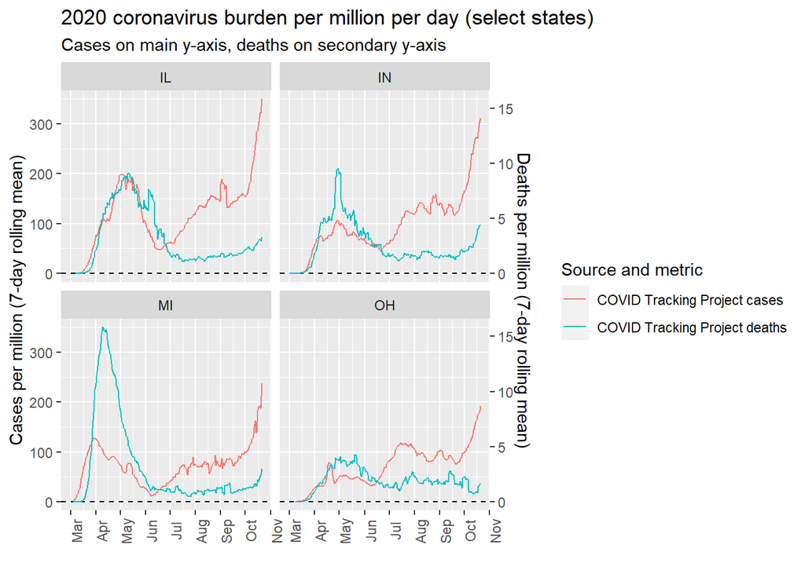

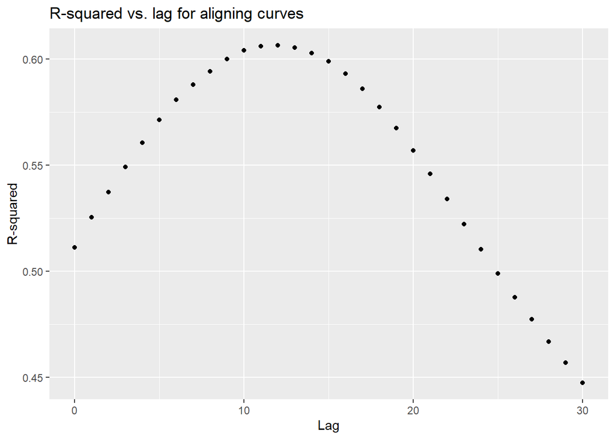

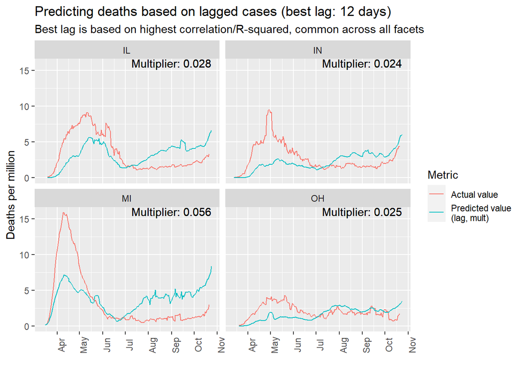

```r
# Example for midwestern states
mwCurveList <- createAndAlignCurves(stateData,
                                    yVal="vpm7",
                                    namesPlot=c("CTP_cases"),
                                    namesSec=c("CTP_deaths"),
                                    keyStates=c("OH", "MI", "IN", "IL"),
                                    plotTitle="2020 coronavirus burden per million per day (select states)",
                                    plotSub="Cases on main y-axis, deaths on secondary y-axis",
                                    primYLab="Cases per million (7-day rolling mean)",
                                    secYLab="Deaths per million (7-day rolling mean)",
                                    facetFixed=TRUE,
                                    popData=usafPrepped$usafDemo,
                                    printPlot=TRUE,
                                    lagValueMetric="vpm7",
                                    lagDepName="CTP_deaths",
                                    lagsTry=0:30
                                    )
```

The midwestern states show the need for the lag value and multiplier to change over time. When a state has a single epidemic peak, such as NY/NJ, metrics can align around values as of the peak. When a state has multiple peaks or smoldering disease (on the x or y metric), then a single value for lag with a single multiplier fails to align the curves.

As an example, the 5.6% deaths vs. cases estimate for Michigan is much too low in April-May and much too high in August-October.

Suppose that separate multipliers are allowed in every month (a likely driver of overfit, but potentially helpful for assessing trends):

```r
# Extract the Michigan data
miData <- mwCurveList$dfList %>%
    filter(state=="MI", !is.na(vpm7)) %>%
    pivot_wider(names_from="name", values_from="vpm7")

# Suppose that a 10-day lag and 20-day lag are calculated, and that lag grows linearly from April 1 -Sep 30
fullTime <- as.integer(as.Date("2020-09-30")-as.Date("2020-03-31"))
miData <- miData %>%
    arrange(state, date) %>%
    group_by(state) %>%
    mutate(lag10=lag(CTP_cases, 10),
           lag20=lag(CTP_cases, 20),
           pct10=pmin(pmax(as.integer(as.Date("2020-09-30")-date)/fullTime, 0), 1),
           indepVar=ifelse(is.na(lag10), NA, pct10*lag10 + (1-pct10)*ifelse(is.na(lag20), 0, lag20)),
           mon=factor(month.abb[lubridate::month(date)], levels=month.abb)
           ) %>%
    ungroup()

# Regression for Michigan data
miLM <- lm(CTP_deaths ~ indepVar:mon + 0, data=miData)
summary(miLM)
```

```
##
## Call:
## lm(formula = CTP_deaths ~ indepVar:mon + 0, data = miData)
##
## Residuals:
##      Min       1Q   Median       3Q      Max
## -2.35211 -0.28842 -0.03148  0.32132  2.27188
##
## Coefficients:
##                 Estimate Std. Error t value Pr(>|t|)
## indepVar:monMar 0.089415   0.002944  30.375  < 2e-16 ***
## indepVar:monApr 0.121001   0.001069 113.146  < 2e-16 ***
## indepVar:monMay 0.064522   0.001539  41.934  < 2e-16 ***
## indepVar:monJun 0.040358   0.003812  10.588  < 2e-16 ***
## indepVar:monJul 0.017567   0.002592   6.776 1.18e-10 ***
## indepVar:monAug 0.013901   0.001574   8.830 3.81e-16 ***
## indepVar:monSep 0.014323   0.001501   9.544  < 2e-16 ***
## indepVar:monOct 0.019051   0.001591  11.975  < 2e-16 ***
## ---
## Signif. codes:  0 '***' 0.001 '**' 0.01 '*' 0.05 '.' 0.1 ' ' 1
##
## Residual standard error: 0.6312 on 214 degrees of freedom
##   (10 observations deleted due to missingness)
## Multiple R-squared:  0.9868, Adjusted R-squared:  0.9863
## F-statistic:  1994 on 8 and 214 DF,  p-value: < 2.2e-16
```

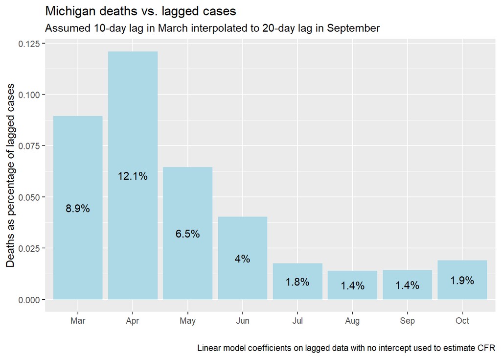

```r
# Plot of deaths vs cases rate by month
coef(miLM) %>%
    as.data.frame() %>%
    purrr::set_names("CFR") %>%
    tibble::rownames_to_column("mon") %>%
    mutate(mon=factor(stringr::str_replace(mon, pattern="indepVar:mon", replacement=""), levels=month.abb)) %>%
    ggplot(aes(x=mon, y=CFR)) +
    geom_col(fill="lightblue") +
    geom_text(aes(y=CFR/2, label=paste0(round(100*CFR, 1), "%"))) +
    labs(x="",
         y="Deaths as percentage of lagged cases",
         title="Michigan deaths vs. lagged cases",
         subtitle="Assumed 10-day lag in March interpolated to 20-day lag in September",
         caption="Linear model coefficients on lagged data with no intercept used to estimate CFR"
         )
```

As expected, CFR is very different in the early peak and in the later forms of disease. The above is converted to a function so that other states can be assessed (again using a rule-of-thumb rather than calculation for lag time periods):

```
## Note: Using an external vector in selections is ambiguous.
## i Use `all_of(keyMetric)` instead of `keyMetric` to silence this message.
## i See <https://tidyselect.r-lib.org/reference/faq-external-vector.html>.
```

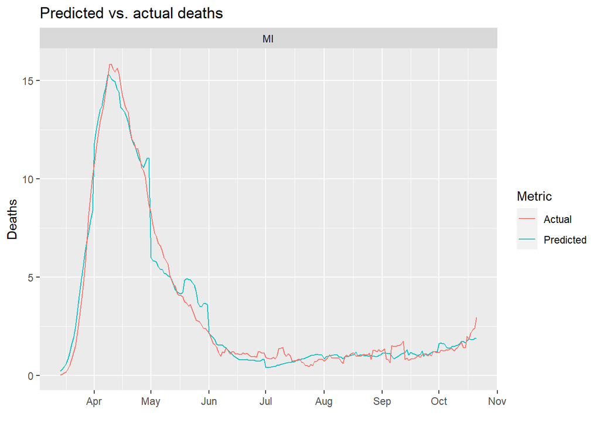

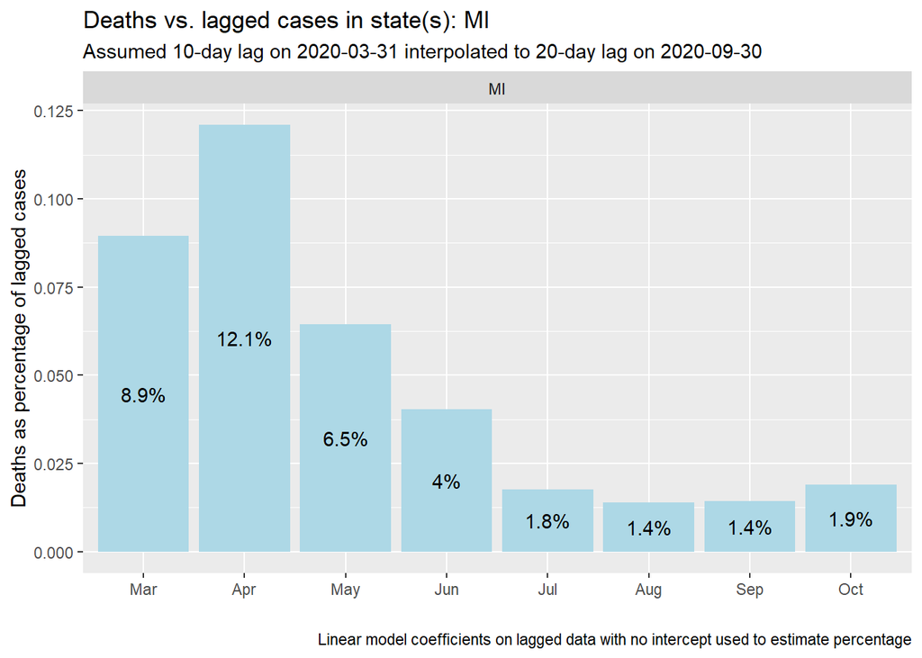

```
## # A tibble: 222 x 11
##    state date       CTP_cases CTP_deaths lag10 lag20 pct10     x      y mon
##    <chr> <date>         <dbl>      <dbl> <dbl> <dbl> <dbl> <dbl>  <dbl> <fct>
##  1 MI    2020-03-14      45.1     0.0288  2.51    NA     1  2.51 0.0288 Mar
##  2 MI    2020-03-15      54.8     0.0720  3.41    NA     1  3.41 0.0720 Mar
##  3 MI    2020-03-16      61.6     0.144   4.97    NA     1  4.97 0.144  Mar
##  4 MI    2020-03-17      69.9     0.187   6.88    NA     1  6.88 0.187  Mar
##  5 MI    2020-03-18      76.2     0.331   9.40    NA     1  9.40 0.331  Mar
##  6 MI    2020-03-19      81.1     0.518  12.9     NA     1 12.9  0.518  Mar
##  7 MI    2020-03-20      88.8     0.821  17.6     NA     1 17.6  0.821  Mar
##  8 MI    2020-03-21      93.5     1.21   22.2     NA     1 22.2  1.21   Mar
##  9 MI    2020-03-22      98.0     1.53   27.9     NA     1 27.9  1.53   Mar
## 10 MI    2020-03-23     104.      2.15   36.3     NA     1 36.3  2.15   Mar
## # ... with 212 more rows, and 1 more variable: pred <dbl>
```

```r
assessStateCFR <- function(lst,
                           keyStates,
                           depVar,
                           indepVar,
                           depTitleName,
                           indepTitleName,
                           keyMetric="vpm7",
                           lagEarlyDate=as.Date("2020-03-31"),
                           lagLateDate=as.Date("2020-09-30"),
                           lagEarlyValue=10,
                           lagLateValue=20
                           ) {

    # FUNCTION ARGUMENTS:
    # lst: A list such as produced by createAndAlignCurves()
    # keyStates: The key states to be extracted from the list
    # depVar: the dependent variable
    # indepVar: the independent variable
    # depTitleName: the name for the dependent variable in the title
    # indepTitleName: the name for the independent variable in the plot title
    # keyMetric: the name of the key metric that is being assessed
    # lagEarlyDate: the date for the earliest lagging calculation (dates before this will be at lagEarlyValue)
    # lagLateDate: the date for the latest lagging calculation (dates after this will be at lagLateValue)
    # lagEarlyValue: the value for lag on lagEarlyDate, will be linearly interpolated to lagLateValue/Date
    # lagLateValue: the value for lag on lagLateDate, will be linearly interpolated from lagEarlyValue/Date

    # Extract the data for keyStates
    df <- lst[["dfList"]] %>%
        filter(state %in% keyStates, !is.na(get(keyMetric))) %>%
        pivot_wider(names_from="name", values_from=keyMetric)

    # Apply the assumed lagging information
    fullTime <- as.integer(lagLateDate-lagEarlyDate)
    df <- df %>%
        arrange(state, date) %>%
        group_by(state) %>%
        mutate(lag10=lag(get(indepVar), lagEarlyValue),
               lag20=lag(get(indepVar), lagLateValue),
               pct10=pmin(pmax(as.integer(lagLateDate-date)/fullTime, 0), 1),
               x=ifelse(is.na(lag10), NA, pct10*lag10 + (1-pct10)*ifelse(is.na(lag20), 0, lag20)),
               y=get(depVar),
               mon=factor(month.abb[lubridate::month(date)], levels=month.abb)
               ) %>%
        filter(!is.na(x)) %>%
        ungroup()

    # Regression for data from keyStates
    if (length(keyStates) > 1) stateLM <- lm(y ~ x:mon:state + 0, data=df)
    else stateLM <- lm(y ~ x:mon + 0, data=df)

    # Add the predicted value to df
    df <- df %>%
        mutate(pred=predict(stateLM))

    # Plot of curve overlaps
    p1 <- df %>%
        select(state, date, y, pred) %>%
        pivot_longer(-c(state, date)) %>%
        ggplot(aes(x=date, y=value)) +
        geom_line(aes(color=c("pred"="Predicted", "y"="Actual")[name], group=name)) +
        scale_x_date(date_breaks="1 month", date_labels="%b") +
        labs(x="",
             y=stringr::str_to_title(depTitleName),
             title=paste0("Predicted vs. actual ", depTitleName)
             ) +
        scale_color_discrete("Metric") +
        facet_wrap(~state)
    print(p1)

    # Plot of rate by month
    p2 <- coef(stateLM) %>%
        as.data.frame() %>%
        purrr::set_names("CFR") %>%
        tibble::rownames_to_column("monState") %>%
        mutate(mon=factor(stringr::str_replace_all(monState, pattern="x:mon|:state.+", replacement=""),
                          levels=month.abb
                          ),
               state=if (length(keyStates)==1) keyStates
                     else stringr::str_replace_all(monState, pattern="x:mon[A-Za-z]{3}:state", replacement="")
               ) %>%
        ggplot(aes(x=mon, y=CFR)) +
        geom_col(fill="lightblue") +
        geom_text(aes(y=CFR/2, label=paste0(round(100*CFR, 1), "%"))) +
        labs(x="",
             y=paste0(stringr::str_to_title(depTitleName), " as percentage of lagged ", indepTitleName),
             title=paste0(stringr::str_to_title(depTitleName),
                          " vs. lagged ",
                          indepTitleName,
                          " in state(s): ",
                          paste0(keyStates, collapse=", ")
                          ),
             subtitle=paste0("Assumed ",
                             lagEarlyValue,
                             "-day lag on ",
                             lagEarlyDate,
                             " interpolated to ",
                             lagLateValue,
                             "-day lag on ",
                             lagLateDate
                             ),
             caption="Linear model coefficients on lagged data with no intercept used to estimate percentage"
             ) +
        facet_wrap(~state)
    print(p2)

    # Return the data frame
    df

}

# Deaths vs. cases in Michigan
assessStateCFR(mwCurveList,
               keyStates="MI",
               depVar="CTP_deaths",
               indepVar="CTP_cases",
               depTitleName="deaths",
               indepTitleName="cases"
               )
```

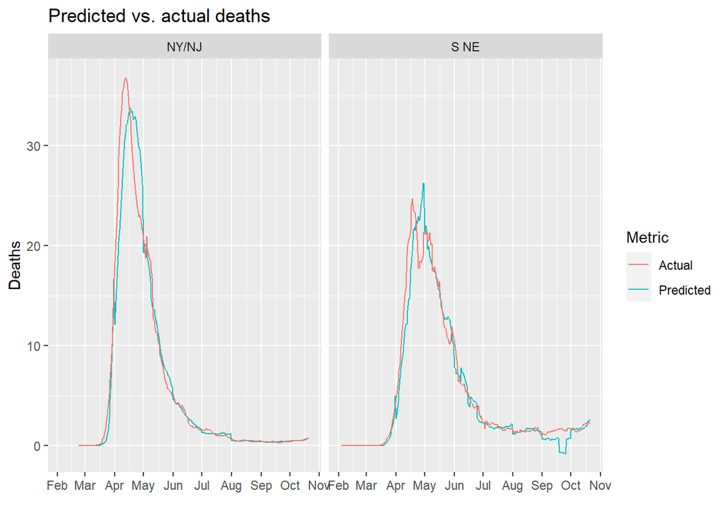

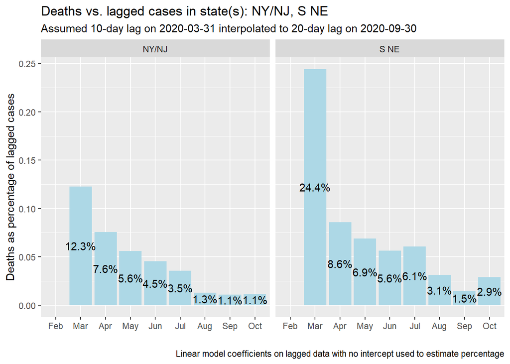

```
## # A tibble: 494 x 12
##    state date          pop CTP_cases CTP_deaths lag10 lag20 pct10     x     y
##    <chr> <date>      <dbl>     <dbl>      <dbl> <dbl> <dbl> <dbl> <dbl> <dbl>
##  1 NY/NJ 2020-02-23 8.96e6    0               0     0    NA     1     0     0
##  2 NY/NJ 2020-02-24 8.96e6    0               0     0    NA     1     0     0
##  3 NY/NJ 2020-02-25 8.96e6    0               0     0    NA     1     0     0
##  4 NY/NJ 2020-02-26 8.96e6    0               0     0    NA     1     0     0
##  5 NY/NJ 2020-02-27 8.96e6    0               0     0    NA     1     0     0
##  6 NY/NJ 2020-02-28 8.96e6    0               0     0    NA     1     0     0
##  7 NY/NJ 2020-02-29 8.96e6    0               0     0    NA     1     0     0
##  8 NY/NJ 2020-03-01 8.96e6    0               0     0    NA     1     0     0
##  9 NY/NJ 2020-03-02 8.96e6    0.0159          0     0    NA     1     0     0
## 10 NY/NJ 2020-03-03 8.96e6    0.0159          0     0    NA     1     0     0
## # ... with 484 more rows, and 2 more variables: mon <fct>, pred <dbl>
```

```r
# Deaths vs. cases in NY/NJ and S NE
assessStateCFR(neCurveList,
               keyStates=c("NY/NJ", "S NE"),
               depVar="CTP_deaths",
               indepVar="CTP_cases",
               depTitleName="deaths",
               indepTitleName="cases"
               )
```

A few findings include:

1. Allowing the rate to change over time significantly improves fit for Michigan (and likely for other states that do not have solely a single peak epidemic)
2. Assuming a lag appears sub-optimal for NY/NJ and S NE where the peak of the epidemic is better suited for finding a lag through data rather than a heuristic

Next steps include 1) finding the lag automatically while allowing for change over time; and 2) smoothing monthly CFR borders that drives spikes/cliffs in predicted values at the month end/start.

The function assessStateCFR() is updated to allow for automatically finding the best early and/or late lag:

```
## # A tibble: 3 x 3
##   state earlyLag lateLag
##   <chr>    <int>   <int>
## 1 IN           2       5
## 2 IL           5       0
## 3 MI          10       0
```

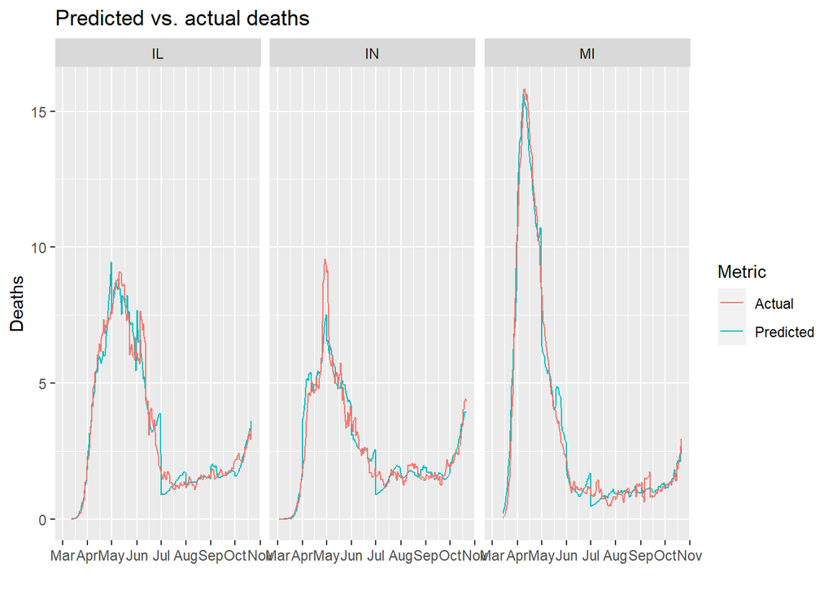

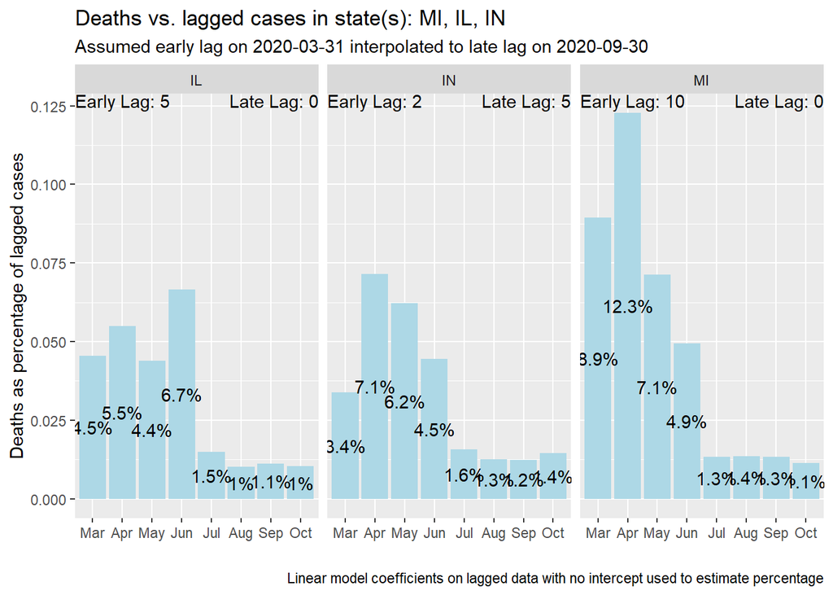

```r
# Updated for automatic lag time assessment
assessStateCFR <- function(lst,
                           keyStates,
                           depVar,
                           indepVar,
                           depTitleName,
                           indepTitleName,
                           keyMetric="vpm7",
                           lagEarlyDate=as.Date("2020-03-31"),
                           lagMidDate=NULL,
                           lagLateDate=as.Date("2020-09-30"),
                           lagEarlyValue=10,
                           lagLateValue=20,
                           lagsTry=0:30
                           ) {

    # FUNCTION ARGUMENTS:
    # lst: A list such as produced by createAndAlignCurves()
    # keyStates: The key states to be extracted from the list
    # depVar: the dependent variable
    # indepVar: the independent variable
    # depTitleName: the name for the dependent variable in the title
    # indepTitleName: the name for the independent variable in the plot title
    # keyMetric: the name of the key metric that is being assessed
    # lagEarlyDate: the date for the earliest lagging calculation (dates before this will be at lagEarlyValue)
    # lagMidDate: if lags are found from data, what midpoint should be used to split data as early vs late?
    #             NULL means midway between lagEarlyDate and lagLateDate
    # lagLateDate: the date for the latest lagging calculation (dates after this will be at lagLateValue)
    # lagEarlyValue: the value for lag on lagEarlyDate, will be linearly interpolated to lagLateValue/Date
    #                NULL means calculate from data and may differ by state
    # lagLateValue: the value for lag on lagLateDate, will be linearly interpolated from lagEarlyValue/Date
    #               NULL means estimate from data and may differ by state
    # lagsTry: the values for lag to be attempted if lageEarlyValue and/or lagLateValue is NULL

    # Extract the data for keyStates
    df <- lst[["dfList"]] %>%
        filter(state %in% keyStates, !is.na(get(keyMetric))) %>%
        pivot_wider(names_from="name", values_from=keyMetric)

    # Function for finding lag time correlations
    helperLagCor <- function(lt, lf, dp, id) {
        lf %>%
            group_by(state) %>%
            mutate(y=get(dp), x=lag(get(id), lt)) %>%
            summarize(p=cor(x, y, use="complete.obs")) %>%
            ungroup() %>%
            mutate(lag=lt)
    }

    # Middle date for splitting data
    if (is.null(lagMidDate)) lagMidDate <- mean(c(lagEarlyDate, lagLateDate))

    # Get the early lags from the data
    eLag <- map_dfr(.x=lagsTry, .f=helperLagCor, lf=filter(df, date<=lagMidDate), dp=depVar, id=indepVar) %>%
        group_by(state) %>%
        filter(p==max(p)) %>%
        filter(row_number()==1) %>%
        ungroup() %>%
        select(state, earlyLag=lag)

    # Get the late lags from the data
    lLag <- map_dfr(.x=lagsTry, .f=helperLagCor, lf=filter(df, date>lagMidDate), dp=depVar, id=indepVar) %>%
        group_by(state) %>%
        filter(p==max(p)) %>%
        filter(row_number()==1) %>%
        ungroup() %>%
        select(state, lateLag=lag)

    # Create the full lag frame, including substituting the fixed value(s) if provided
    lagFrame <- eLag %>%
        inner_join(lLag, by="state")
    if (!is.null(lagEarlyValue)) lagFrame <- lagFrame %>% mutate(earlyLag=lagEarlyValue)
    if (!is.null(lagLateValue)) lagFrame <- lagFrame %>% mutate(lateLag=lagLateValue)
    print(lagFrame)

    # Apply the assumed lagging information
    fullTime <- as.integer(lagLateDate-lagEarlyDate)
    df <- df %>%
        left_join(lagFrame, by="state") %>%
        arrange(state, date) %>%
        group_by(state) %>%
        mutate(eLag=lag(get(indepVar), mean(earlyLag)),
               lLag=lag(get(indepVar), mean(lateLag)),
               pctEarly=pmin(pmax(as.integer(lagLateDate-date)/fullTime, 0), 1),
               x=ifelse(is.na(eLag), NA, pctEarly*eLag + (1-pctEarly)*ifelse(is.na(lLag), 0, lLag)),
               y=get(depVar),
               mon=factor(month.abb[lubridate::month(date)], levels=month.abb)
               ) %>%
        filter(!is.na(x)) %>%
        ungroup()

    # Regression for data from keyStates
    if (length(keyStates) > 1) stateLM <- lm(y ~ x:mon:state + 0, data=df)
    else stateLM <- lm(y ~ x:mon + 0, data=df)

    # Add the predicted value to df
    df <- df %>%
        mutate(pred=predict(stateLM))

    # Plot of curve overlaps
    p1 <- df %>%
        select(state, date, y, pred) %>%
        pivot_longer(-c(state, date)) %>%
        ggplot(aes(x=date, y=value)) +
        geom_line(aes(color=c("pred"="Predicted", "y"="Actual")[name], group=name)) +
        scale_x_date(date_breaks="1 month", date_labels="%b") +
        labs(x="",
             y=stringr::str_to_title(depTitleName),
             title=paste0("Predicted vs. actual ", depTitleName)
             ) +
        scale_color_discrete("Metric") +
        facet_wrap(~state)
    print(p1)

    # Plot of rate by month
    p2 <- coef(stateLM) %>%
        as.data.frame() %>%
        purrr::set_names("CFR") %>%
        tibble::rownames_to_column("monState") %>%
        mutate(mon=factor(stringr::str_replace_all(monState, pattern="x:mon|:state.+", replacement=""),
                          levels=month.abb
                          ),
               state=if (length(keyStates)==1) keyStates
                     else stringr::str_replace_all(monState, pattern="x:mon[A-Za-z]{3}:state", replacement="")
               ) %>%
        left_join(lagFrame, by="state") %>%
        ggplot(aes(x=mon, y=CFR)) +
        geom_col(fill="lightblue") +
        geom_text(aes(y=CFR/2, label=paste0(round(100*CFR, 1), "%"))) +
        geom_text(data=~filter(., mon==month.abb[lubridate::month(lagMidDate)]),
                  aes(x=-Inf, y=Inf, label=paste0("Early Lag: ", earlyLag)),
                  hjust=0,
                  vjust=1
                  ) +
        geom_text(data=~filter(., mon==month.abb[lubridate::month(lagMidDate)]),
                  aes(x=Inf, y=Inf, label=paste0("Late Lag: ", lateLag)),
                  hjust=1,
                  vjust=1
                  ) +
        labs(x="",
             y=paste0(stringr::str_to_title(depTitleName), " as percentage of lagged ", indepTitleName),
             title=paste0(stringr::str_to_title(depTitleName),
                          " vs. lagged ",
                          indepTitleName,
                          " in state(s): ",
                          paste0(keyStates, collapse=", ")
                          ),
             subtitle=paste0("Assumed early lag on ",
                             lagEarlyDate,
                             " interpolated to late lag on ",
                             lagLateDate
                             ),
             caption="Linear model coefficients on lagged data with no intercept used to estimate percentage"
             ) +
        facet_wrap(~state)
    print(p2)

    # Return the data frame
    df

}

# Deaths vs. cases in Michigan
mwOut <- assessStateCFR(mwCurveList,
                        keyStates=c("MI", "IL", "IN"),
                        depVar="CTP_deaths",
                        indepVar="CTP_cases",
                        depTitleName="deaths",
                        indepTitleName="cases",
                        lagEarlyValue=NULL,
                        lagLateValue=NULL
                        )
```

```
## # A tibble: 2 x 3
##   state earlyLag lateLag
##   <chr>    <int>   <int>
## 1 NY/NJ        6      30
## 2 S NE         7       0
```

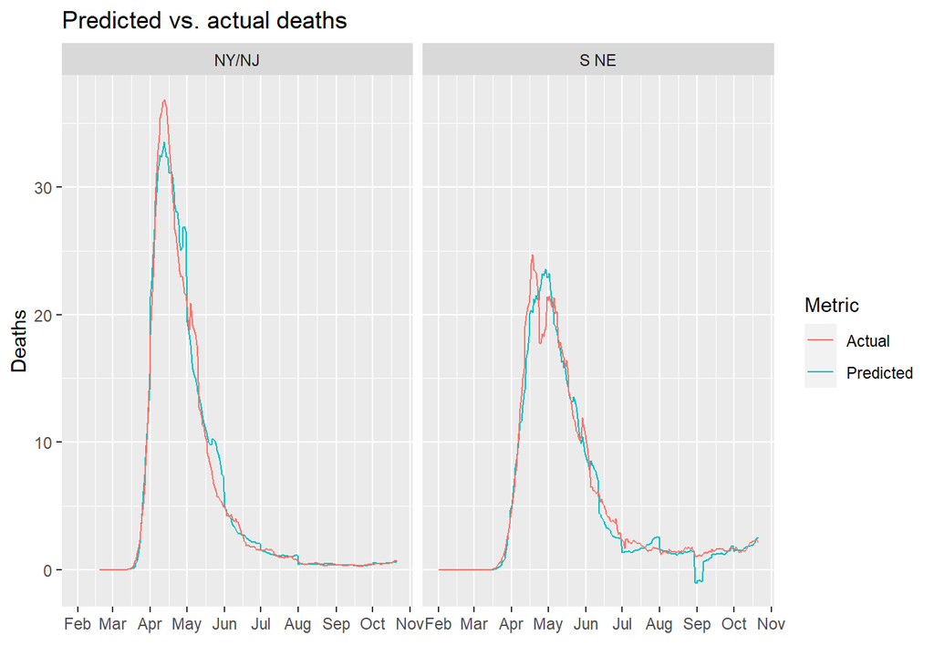

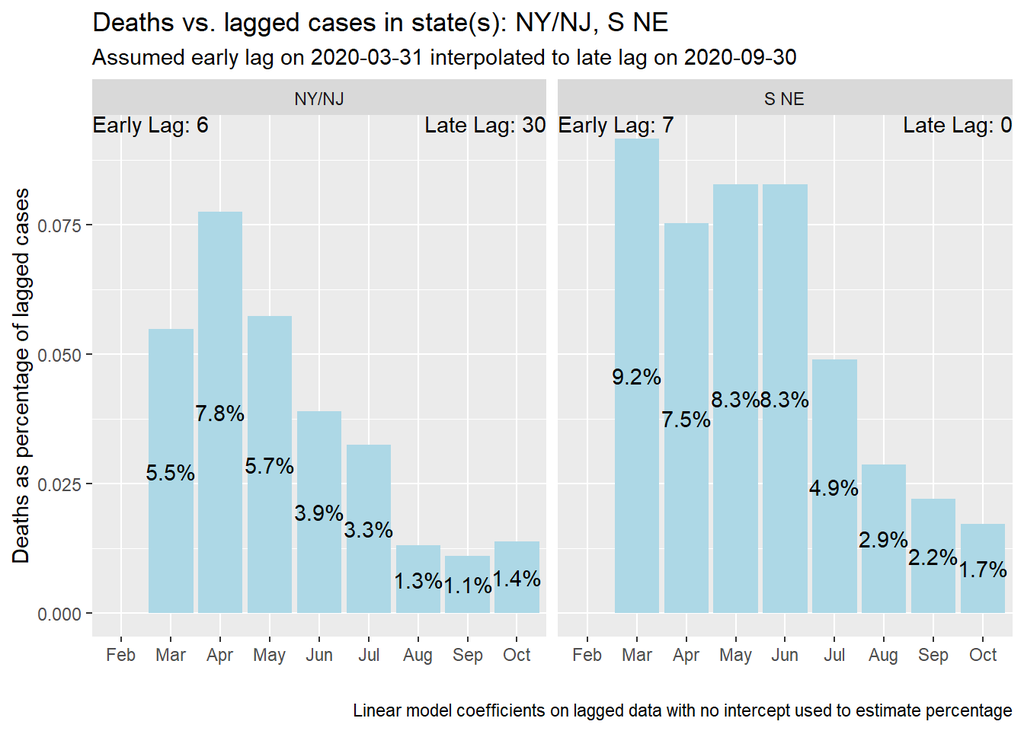

```r
# Deaths vs. cases in NY/NJ and S NE
neOut <- assessStateCFR(neCurveList,
                        keyStates=c("NY/NJ", "S NE"),
                        depVar="CTP_deaths",
                        indepVar="CTP_cases",
                        depTitleName="deaths",
                        indepTitleName="cases",
                        lagEarlyValue=NULL,
                        lagLateValue=NULL
                        )
```

The ability to have data-driven lags by state improves the fit. Next steps are to work on smoothing the scaling factor over time.